# IPCEI Collaboration Analysis — Technology-Tagged Composition Outcomes

Tech-tagged intensity, cross-border, cross-sector | Callaway & Sant’Anna DiD | monthly/quarterly toggle

2026-10-16

# 0. Setup

```r
library(did)
library(dplyr)
library(ggplot2)
library(tidyr)
library(knitr)
library(kableExtra)
library(scales)
library(rbounds)

set.seed(42)

# ============================================================
# TIME UNIT TOGGLE  --  Set to "month" or "quarter".
# ============================================================
TIME_UNIT <- "month"   # "month" (primary) | "quarter" (robustness)

# Significance threshold for "findings" -- drives BOTH the Rosenbaum selection
# (section 7) and the power-simulation selection (section 9), so they always
# agree on which outcomes count.
SIG_THRESHOLD <- 0.10  # outcomes counted as findings

PATH_BATTERY_S1        <- "../data/battery_psm_spec1_cs_ready.csv"
PATH_HYDROGEN_S1       <- "../data/hydrogen_psm_spec1_cs_ready.csv"
PATH_BATTERY_S2        <- "../data/battery_psm_spec2_cs_ready.csv"
PATH_HYDROGEN_S2       <- "../data/hydrogen_psm_spec2_cs_ready.csv"
PATH_BATTERY_FIRMS_S1  <- "../data/battery_psm_spec1_matched_firms.csv"
PATH_HYDROGEN_FIRMS_S1 <- "../data/hydrogen_psm_spec1_matched_firms.csv"
PATH_BATTERY_FIRMS_S2  <- "../data/battery_psm_spec2_matched_firms.csv"
PATH_HYDROGEN_FIRMS_S2 <- "../data/hydrogen_psm_spec2_matched_firms.csv"

out_dir <- file.path("../results/psm/composition_techtagged", TIME_UNIT)
dir.create(out_dir, showWarnings = FALSE, recursive = TRUE)
```

# 1. Load & Prepare Data

Two changes versus the original `load_cs()`:

1. **Contiguous integer period index.** The original coded `period` as `YYYY*100 + MM` (e.g. 202012, 202101). `aggte(type = "dynamic")` computes event time as `e = t - g` from the *raw* `tname`/`gname` values, so across a year boundary that difference is 89, not 1. The `type = "simple"` aggregation that feeds the headline table is unaffected (it only needs the post/pre ordering), but the dynamic event-study plots and the `min_e`/`max_e` windows are distorted. Coding `period` as a dense rank (1, 2, 3, …) makes both aggregations correct regardless of `did` version.
2. **Quarterly aggregation.** When `TIME_UNIT == "quarter"`, raw monthly counts are summed within firm-quarter *before* the `log1p`, and `g` is floored to the quarter that contains the approval date. Aggregating the counts and then logging (rather than averaging monthly logs) is the correct order for an additive count outcome.

```r
# Floor a Date to the start of its time unit
floor_unit <- function(d, unit = TIME_UNIT) {
  if (unit == "month") {
    as.Date(format(d, "%Y-%m-01"))
  } else {  # quarter
    q  <- (as.integer(format(d, "%m")) - 1L) %/% 3L          # 0..3
    mm <- sprintf("%02d", q * 3L + 1L)                       # 01,04,07,10
    as.Date(paste0(format(d, "%Y"), "-", mm, "-01"))
  }
}

# All n_collabs* columns are outcome counts; everything else is meta/covariate
count_cols <- function(df) grep("^n_collabs", names(df), value = TRUE)
```

```r
load_cs <- function(path, unit = TIME_UNIT) {
  df <- read.csv(path, stringsAsFactors = FALSE)
  df$month <- as.Date(df$month)

  ccols <- count_cols(df)

  # Covariates that are constant within firm (carried through aggregation)
  firm_cov <- c("g", "is_treated", "is_control", "matched_to",
                "nace1_psm", "nace1_proxy", "firm_type",
                "log_staffCount", "age",
                "log_collab_count_2020", "degree_centrality_2020")
  firm_cov <- intersect(firm_cov, names(df))

  # ── Collapse to the chosen time unit ───────────────────────────────────────
  df$tunit <- floor_unit(df$month, unit)

  # Level outcomes (per-month means, e.g. consortium size) are AVERAGED within
  # firm-quarter, NOT summed like the counts. (Absent in old panels -> no-op.)
  level_cols <- intersect(c("mean_collab_size", "mean_collab_size_active"), names(df))

  if (unit == "quarter") {
    counts <- df %>%
      group_by(Linkedin_name, tunit) %>%
      summarise(across(all_of(ccols), ~ sum(.x, na.rm = TRUE)),
                .groups = "drop")
    meta <- df %>%
      group_by(Linkedin_name) %>%
      summarise(across(all_of(firm_cov), ~ dplyr::first(.x)),
                .groups = "drop")
    levels_q <- if (length(level_cols)) df %>%
      group_by(Linkedin_name, tunit) %>%
      summarise(across(all_of(level_cols), ~ mean(.x, na.rm = TRUE)),  # AVERAGE, not sum
                .groups = "drop") else NULL
    df <- counts %>% left_join(meta, by = "Linkedin_name")
    if (!is.null(levels_q)) df <- df %>% left_join(levels_q, by = c("Linkedin_name", "tunit"))
  } else {
    # monthly: tunit == month, nothing to sum, just keep one row per firm-month
    # (.keep_all carries mean_collab_size through unchanged)
    df <- df %>% distinct(Linkedin_name, tunit, .keep_all = TRUE)
  }

  # ── Contiguous integer period index (1..T) ─────────────────────────────────
  u_periods   <- sort(unique(df$tunit))
  period_idx  <- setNames(seq_along(u_periods), as.character(u_periods))
  df$period   <- as.integer(period_idx[as.character(df$tunit)])

  # ── g_period on the same contiguous scale (0 = never-treated) ───────────────
  df$g <- as.character(df$g)
  df$g[df$g == "" | df$g == "NA"] <- NA
  g_unit <- floor_unit(as.Date(df$g), unit)
  df$g_period <- period_idx[as.character(g_unit)]
  df$g_period[is.na(df$g_period)] <- 0L
  df$g_period <- as.numeric(df$g_period)

  df$firm_id <- as.integer(factor(df$Linkedin_name))

  # ── log1p every count column generically -> log_<name> ─────────────────────
  for (cc in ccols) {
    df[[sub("^n_collabs", "log_collabs", cc)]] <- log1p(df[[cc]])
  }

  # ── extensive-margin (binary) version of every count column ────────────────
  for (cc in ccols) {
    df[[sub("^n_collabs", "any_collabs", cc)]] <- as.integer(df[[cc]] > 0)
  }

  df
}

battery_s1  <- load_cs(PATH_BATTERY_S1)
hydrogen_s1 <- load_cs(PATH_HYDROGEN_S1)
battery_s2  <- load_cs(PATH_BATTERY_S2)
hydrogen_s2 <- load_cs(PATH_HYDROGEN_S2)

cat("TIME_UNIT =", TIME_UNIT, "\n")
```

```
## TIME_UNIT = month
```

```r
# PRIMARY specification = tighter-balance spec (spec1: battery_s1, hydrogen_s1).
# ROBUSTNESS = larger-control-group power spec (spec2: battery_s2, hydrogen_s2).
cat("Battery (primary, balance):",  n_distinct(battery_s1$Linkedin_name), "firms,",
    n_distinct(battery_s1$period), "periods\n")
```

```
## Battery (primary, balance): 115 firms, 72 periods
```

```r
cat("Hydrogen (primary, balance):", n_distinct(hydrogen_s1$Linkedin_name), "firms,",
    n_distinct(hydrogen_s1$period), "periods\n")
```

```
## Hydrogen (primary, balance): 265 firms, 72 periods
```

```r
# ============================================================
# Outcome map: which column each technology uses.
# ============================================================
#
#   label                     battery column                 hydrogen column
#   ------------------------  -----------------------------  ------------------------------
#   technology-tagged (intens.)  log_collabs_battery         log_collabs_hydrogen
#   cross-border EU           log_collabs_eu_crossborder_battery  ..._hydrogen
#   cross-sector              log_collabs_crosssector_battery     ..._hydrogen
#   cross-sector (EU only)    log_collabs_crosssector_eu_battery  ..._hydrogen   [optional]
#   non-EU (placebo)          log_collabs_non_eu_battery          ..._hydrogen
#   domestic (placebo)        log_collabs_domestic_battery        ..._hydrogen
#   within-sector (placebo)   log_collabs_withinsector_battery    ..._hydrogen
#   cross-sector (NACE-1)     log_collabs_crosssector_nace1_battery  ..._hydrogen  [robustness]
#
outcome_map <- list(
  tech_focused = c(battery = "log_collabs_battery",
                   hydrogen = "log_collabs_hydrogen"),
  cross_border = c(battery = "log_collabs_eu_crossborder_battery",
                   hydrogen = "log_collabs_eu_crossborder_hydrogen"),
  cross_sector = c(battery = "log_collabs_crosssector_battery",
                   hydrogen = "log_collabs_crosssector_hydrogen"),
  cross_sector_eu = c(battery = "log_collabs_crosssector_eu_battery",
                      hydrogen = "log_collabs_crosssector_eu_hydrogen"),
  non_eu = c(battery = "log_collabs_non_eu_battery",
             hydrogen = "log_collabs_non_eu_hydrogen"),
  domestic = c(battery = "log_collabs_domestic_battery",
               hydrogen = "log_collabs_domestic_hydrogen"),
  within_sector = c(battery = "log_collabs_withinsector_battery",
                    hydrogen = "log_collabs_withinsector_hydrogen"),
  # Redirection benchmark: collaboration OUTSIDE the funded technology
  # (total minus technology-tagged, built in nb03).
  non_funded    = c(battery = "log_collabs_nonfunded_battery",
                    hydrogen = "log_collabs_nonfunded_hydrogen"),
  # Robustness: cross-sector at NACE-1 resolution (nace2_proxy_nace1).
  # Same column auto-log-transformed by load_cs; primary cross_sector stays NACE-2.
  cross_sector_nace1 = c(battery = "log_collabs_crosssector_nace1_battery",
                         hydrogen = "log_collabs_crosssector_nace1_hydrogen")
)
```

```r
# Zero shares among TREATED firm-periods (the binding constraint on power).
# Watch this when you flip to quarterly: it should drop noticeably.
zero_share_report <- function(df_b, df_h, map) {
  rows <- lapply(names(map), function(k) {
    cb <- sub("^log_collabs", "n_collabs", map[[k]]["battery"])
    ch <- sub("^log_collabs", "n_collabs", map[[k]]["hydrogen"])
    zb <- if (cb %in% names(df_b)) mean(df_b[df_b$is_treated == 1, cb] == 0) else NA
    zh <- if (ch %in% names(df_h)) mean(df_h[df_h$is_treated == 1, ch] == 0) else NA
    data.frame(outcome = k,
               battery_zero_pct  = round(100 * zb, 1),
               hydrogen_zero_pct = round(100 * zh, 1))
  })
  do.call(rbind, rows)
}
cat("\n--- Zero shares (treated firm-", TIME_UNIT, "s) ---\n", sep = "")
```

```
##
## --- Zero shares (treated firm-months) ---
```

```r
print(zero_share_report(battery_s1, hydrogen_s1, outcome_map), row.names = FALSE)
```

```
##             outcome battery_zero_pct hydrogen_zero_pct
##        tech_focused             70.7              53.1
##        cross_border             81.0              70.8
##        cross_sector             72.6              54.9
##     cross_sector_eu             76.6              59.1
##              non_eu             78.2              66.0
##            domestic             82.8              62.5
##       within_sector             86.4              72.1
##          non_funded             78.5              68.4
##  cross_sector_nace1             76.2              57.4
```

# 2. C&S Estimation — Helper Functions

```r
run_cs <- function(df, yname, label = "",
                   control_group = "notyettreated",
                   clustervars   = NULL) {
  cat("\n=== C&S:", label, "(", yname, ") ===\n")
  if (!yname %in% names(df)) {
    cat("  !! column", yname, "not found -- skipping\n"); return(NULL)
  }
  # Deterministic per-outcome seed: makes every estimate reproducible and
  # independent of how many other outcomes ran earlier in the same session.
  # With a single set.seed() up front, adding one outcome shifts the bootstrap
  # stream for every later run and moves all downstream p-values.
  set.seed(42L + sum(utf8ToInt(paste0(yname, control_group))))
  cs_out <- att_gt(
    yname = yname, tname = "period", idname = "firm_id", gname = "g_period",
    control_group = control_group, clustervars = clustervars,
    anticipation = 0,   # paper assumption: treatment date = EC approval, no anticipation
    bstrap = TRUE, biters = BITERS, panel = TRUE, pl = TRUE, data = df
  )
  print(summary(cs_out))
  cs_out
}

agg_simple  <- function(cs) if (is.null(cs)) NULL else aggte(cs, type = "simple")
agg_dynamic <- function(cs) if (is.null(cs)) NULL else
  aggte(cs, type = "dynamic", min_e = -12, max_e = 24)

pval_from_att <- function(att, se) round(2 * pnorm(-abs(att / se)), 3)

sample_stats <- function(df, yname) {
  d <- df %>% filter(!is.na(.data[[yname]]), !is.na(firm_id),
                     !is.na(period), !is.na(g_period))
  data.frame(N_obs = nrow(d), N_units = n_distinct(d$firm_id),
             N_treated = n_distinct(d$firm_id[d$g_period > 0]))
}

# Pre-trend test. Primary is did's universal Wald pre-test (cs_out$Wpval). For
# staggered designs that bootstrap covariance is singular and att_gt returns no
# Wald (hydrogen, confirmed -- it stays NULL under never- AND not-yet-treated).
# In that case fall back to a joint test that the pre-period (e < 0) dynamic
# event-study coefficients are zero: a chi-square of their t-statistics from
# aggte(type="dynamic") att.egt/se.egt (analytic SEs, df = # pre-periods). The
# `method` field records which test was used.
es_pretrend <- function(cs_out) {
  if (is.null(cs_out)) return(list(stat = NA_real_, p = NA_real_, method = NA_character_))
  if (!is.null(cs_out$Wpval))
    return(list(stat = round(cs_out$W, 3), p = round(cs_out$Wpval, 3), method = "Wald"))
  dyn <- tryCatch(
    aggte(cs_out, type = "dynamic", min_e = -12, max_e = 24, bstrap = FALSE, cband = FALSE),
    error = function(e) NULL)
  if (is.null(dyn)) return(list(stat = NA_real_, p = NA_real_, method = NA_character_))
  pre <- dyn$egt < 0
  t2  <- (dyn$att.egt[pre] / dyn$se.egt[pre])^2
  ok  <- is.finite(t2); k <- sum(ok)
  if (k == 0) return(list(stat = NA_real_, p = NA_real_, method = NA_character_))
  stat <- sum(t2[ok])
  list(stat = round(stat, 3), p = round(1 - pchisq(stat, df = k), 3), method = "ES-joint")
}

make_att_row <- function(agg_obj, technology, outcome, type = "Primary",
                         cs_out = NULL, df = NULL, yname = NULL) {
  if (is.null(agg_obj)) return(NULL)
  stats <- if (!is.null(df) && !is.null(yname)) sample_stats(df, yname) else
    data.frame(N_obs = NA, N_units = NA, N_treated = NA)
  pt <- es_pretrend(cs_out)
  data.frame(
    Technology = technology, Outcome = outcome, Type = type,
    TimeUnit   = TIME_UNIT,
    ATT = round(agg_obj$overall.att, 4),
    SE  = round(agg_obj$overall.se, 4),
    p_value = pval_from_att(agg_obj$overall.att, agg_obj$overall.se),
    pretrend_stat    = pt$stat,
    pretrend_p_value = pt$p,
    pretrend_test    = pt$method,
    N_obs = stats$N_obs, N_units = stats$N_units, N_treated = stats$N_treated,
    stringsAsFactors = FALSE
  )
}

plot_cs <- function(agg_dyn, title) {
  if (is.null(agg_dyn)) return(NULL)
  ggdid(agg_dyn, title = title) +
    geom_vline(xintercept = -0.5, linetype = "dashed", colour = "grey40") +
    theme_minimal(base_size = 12) +
    labs(x = paste0(toupper(substring(TIME_UNIT, 1, 1)),
                    substring(TIME_UNIT, 2), "s relative to treatment"),
         y = "ATT(g,t)")
}

# Primary C&S control group: NEVER-TREATED for BOTH technologies. Some firms are
# treated in multiple IPCEI rounds, so a not-yet-treated firm may already be
# affected by an earlier treatment and contaminate the control pool; never-treated
# controls avoid this and make the two technologies symmetric. (Battery is a
# single cohort, which independently requires never-treated.) The not-yet-treated
# alternative is reported as one robustness row for hydrogen (section 6).
cg_for <- function(technology) "nevertreated"

# Convenience: run battery + hydrogen for one outcome key from outcome_map.
# Primary spec: never-treated controls + firm-level clustering, both technologies.
run_pair <- function(key, label) {
  list(
    battery  = run_cs(battery_s1,  outcome_map[[key]]["battery"],
                      paste("Battery S2 --", label),
                      control_group = cg_for("battery"),
                      clustervars   = "firm_id"),
    hydrogen = run_cs(hydrogen_s1, outcome_map[[key]]["hydrogen"],
                      paste("Hydrogen S2 --", label),
                      control_group = cg_for("hydrogen"),
                      clustervars   = "firm_id")
  )
}
```

# 3. Main Outcomes (technology-tagged)

```r
cs_tech <- run_pair("tech_focused", "technology-tagged intensity")
```

```
##
## === C&S: Battery S2 -- technology-tagged intensity ( log_collabs_battery ) ===
##
## Call:
## att_gt(yname = yname, tname = "period", idname = "firm_id", gname = "g_period",
##     data = df, panel = TRUE, control_group = control_group, anticipation = 0,
##     bstrap = TRUE, biters = BITERS, clustervars = clustervars,
##     pl = TRUE)
##
## Reference: Callaway, Brantly and Pedro H.C. Sant'Anna.  "Difference-in-Differences with Multiple Time Periods." Journal of Econometrics, Vol. 225, No. 2, pp. 200-230, 2021. <https://doi.org/10.1016/j.jeconom.2020.12.001>, <https://arxiv.org/abs/1803.09015>
##
## Group-Time Average Treatment Effects:
##  Group Time ATT(g,t) Std. Error [95% Simult.  Conf. Band]
##     13    2   0.0000     0.0709       -0.1958      0.1958
##     13    3   0.0239     0.0391       -0.0841      0.1319
```

[output cut: 78 more lines]

```
##
## Call:
## att_gt(yname = yname, tname = "period", idname = "firm_id", gname = "g_period",
##     data = df, panel = TRUE, control_group = control_group, anticipation = 0,
##     bstrap = TRUE, biters = BITERS, clustervars = clustervars,
##     pl = TRUE)
##
## Reference: Callaway, Brantly and Pedro H.C. Sant'Anna.  "Difference-in-Differences with Multiple Time Periods." Journal of Econometrics, Vol. 225, No. 2, pp. 200-230, 2021. <https://doi.org/10.1016/j.jeconom.2020.12.001>, <https://arxiv.org/abs/1803.09015>
##
## Group-Time Average Treatment Effects:
##  Group Time ATT(g,t) Std. Error [95% Simult.  Conf. Band]
##     31    2  -0.1219     0.0950       -0.4210      0.1771
##     31    3   0.0030     0.0620       -0.1922      0.1982
##     31    4   0.0631     0.0980       -0.2452      0.3713
##     31    5  -0.0206     0.0495       -0.1765      0.1353
```

[output cut: 286 more lines]

```r
cs_cb   <- run_pair("cross_border", "tech-tagged cross-border EU")
```

```
##
## === C&S: Battery S2 -- tech-tagged cross-border EU ( log_collabs_eu_crossborder_battery ) ===
```

```
##
## Call:
## att_gt(yname = yname, tname = "period", idname = "firm_id", gname = "g_period",
##     data = df, panel = TRUE, control_group = control_group, anticipation = 0,
##     bstrap = TRUE, biters = BITERS, clustervars = clustervars,
##     pl = TRUE)
##
## Reference: Callaway, Brantly and Pedro H.C. Sant'Anna.  "Difference-in-Differences with Multiple Time Periods." Journal of Econometrics, Vol. 225, No. 2, pp. 200-230, 2021. <https://doi.org/10.1016/j.jeconom.2020.12.001>, <https://arxiv.org/abs/1803.09015>
##
## Group-Time Average Treatment Effects:
##  Group Time ATT(g,t) Std. Error [95% Simult.  Conf. Band]
##     13    2   0.0239     0.0342       -0.0687      0.1165
##     13    3  -0.0239     0.0342       -0.1165      0.0687
##     13    4   0.0478     0.0318       -0.0382      0.1338
##     13    5  -0.0099     0.0567       -0.1634      0.1435
```

[output cut: 75 more lines]

```
##
## Call:
## att_gt(yname = yname, tname = "period", idname = "firm_id", gname = "g_period",
##     data = df, panel = TRUE, control_group = control_group, anticipation = 0,
##     bstrap = TRUE, biters = BITERS, clustervars = clustervars,
##     pl = TRUE)
##
## Reference: Callaway, Brantly and Pedro H.C. Sant'Anna.  "Difference-in-Differences with Multiple Time Periods." Journal of Econometrics, Vol. 225, No. 2, pp. 200-230, 2021. <https://doi.org/10.1016/j.jeconom.2020.12.001>, <https://arxiv.org/abs/1803.09015>
##
## Group-Time Average Treatment Effects:
##  Group Time ATT(g,t) Std. Error [95% Simult.  Conf. Band]
##     31    2  -0.0744     0.0873       -0.3409      0.1921
##     31    3   0.0002     0.0516       -0.1572      0.1577
##     31    4   0.0128     0.1007       -0.2947      0.3202
##     31    5  -0.0192     0.0690       -0.2298      0.1914
```

[output cut: 286 more lines]

```r
cs_xs   <- run_pair("cross_sector", "tech-tagged cross-sector")
```

```
##
## === C&S: Battery S2 -- tech-tagged cross-sector ( log_collabs_crosssector_battery ) ===
##
## Call:
## att_gt(yname = yname, tname = "period", idname = "firm_id", gname = "g_period",
##     data = df, panel = TRUE, control_group = control_group, anticipation = 0,
##     bstrap = TRUE, biters = BITERS, clustervars = clustervars,
##     pl = TRUE)
##
## Reference: Callaway, Brantly and Pedro H.C. Sant'Anna.  "Difference-in-Differences with Multiple Time Periods." Journal of Econometrics, Vol. 225, No. 2, pp. 200-230, 2021. <https://doi.org/10.1016/j.jeconom.2020.12.001>, <https://arxiv.org/abs/1803.09015>
##
## Group-Time Average Treatment Effects:
##  Group Time ATT(g,t) Std. Error [95% Simult.  Conf. Band]
##     13    2   0.0239     0.0342       -0.0705      0.1183
##     13    3   0.0239     0.0391       -0.0840      0.1318
```

[output cut: 78 more lines]

```
##
## Call:
## att_gt(yname = yname, tname = "period", idname = "firm_id", gname = "g_period",
##     data = df, panel = TRUE, control_group = control_group, anticipation = 0,
##     bstrap = TRUE, biters = BITERS, clustervars = clustervars,
##     pl = TRUE)
##
## Reference: Callaway, Brantly and Pedro H.C. Sant'Anna.  "Difference-in-Differences with Multiple Time Periods." Journal of Econometrics, Vol. 225, No. 2, pp. 200-230, 2021. <https://doi.org/10.1016/j.jeconom.2020.12.001>, <https://arxiv.org/abs/1803.09015>
##
## Group-Time Average Treatment Effects:
##  Group Time ATT(g,t) Std. Error [95% Simult.  Conf. Band]
##     31    2  -0.1179     0.0953       -0.4191      0.1834
##     31    3  -0.0011     0.0602       -0.1914      0.1893
##     31    4  -0.0166     0.0506       -0.1766      0.1435
##     31    5   0.0475     0.0341       -0.0604      0.1553
```

[output cut: 286 more lines]

```r
cs_xs_n1 <- run_pair("cross_sector_nace1", "tech-tagged cross-sector (NACE-1 resolution)")
```

```
##
## === C&S: Battery S2 -- tech-tagged cross-sector (NACE-1 resolution) ( log_collabs_crosssector_nace1_battery ) ===
##
## Call:
## att_gt(yname = yname, tname = "period", idname = "firm_id", gname = "g_period",
##     data = df, panel = TRUE, control_group = control_group, anticipation = 0,
##     bstrap = TRUE, biters = BITERS, clustervars = clustervars,
##     pl = TRUE)
##
## Reference: Callaway, Brantly and Pedro H.C. Sant'Anna.  "Difference-in-Differences with Multiple Time Periods." Journal of Econometrics, Vol. 225, No. 2, pp. 200-230, 2021. <https://doi.org/10.1016/j.jeconom.2020.12.001>, <https://arxiv.org/abs/1803.09015>
##
## Group-Time Average Treatment Effects:
##  Group Time ATT(g,t) Std. Error [95% Simult.  Conf. Band]
##     13    2   0.0239     0.0342       -0.0713      0.1191
##     13    3   0.0239     0.0379       -0.0815      0.1293
```

[output cut: 78 more lines]

```
##
## Call:
## att_gt(yname = yname, tname = "period", idname = "firm_id", gname = "g_period",
##     data = df, panel = TRUE, control_group = control_group, anticipation = 0,
##     bstrap = TRUE, biters = BITERS, clustervars = clustervars,
##     pl = TRUE)
##
## Reference: Callaway, Brantly and Pedro H.C. Sant'Anna.  "Difference-in-Differences with Multiple Time Periods." Journal of Econometrics, Vol. 225, No. 2, pp. 200-230, 2021. <https://doi.org/10.1016/j.jeconom.2020.12.001>, <https://arxiv.org/abs/1803.09015>
##
## Group-Time Average Treatment Effects:
##  Group Time ATT(g,t) Std. Error [95% Simult.  Conf. Band]
##     31    2  -0.0746     0.1011       -0.3943      0.2452
##     31    3   0.0066     0.0593       -0.1807      0.1940
##     31    4  -0.0623     0.0377       -0.1814      0.0568
##     31    5   0.0008     0.0221       -0.0689      0.0706
```

[output cut: 286 more lines]

```r
cs_neu  <- run_pair("non_eu",       "tech-tagged non-EU (placebo)")
```

```
##
## === C&S: Battery S2 -- tech-tagged non-EU (placebo) ( log_collabs_non_eu_battery ) ===
##
## Call:
## att_gt(yname = yname, tname = "period", idname = "firm_id", gname = "g_period",
##     data = df, panel = TRUE, control_group = control_group, anticipation = 0,
##     bstrap = TRUE, biters = BITERS, clustervars = clustervars,
##     pl = TRUE)
##
## Reference: Callaway, Brantly and Pedro H.C. Sant'Anna.  "Difference-in-Differences with Multiple Time Periods." Journal of Econometrics, Vol. 225, No. 2, pp. 200-230, 2021. <https://doi.org/10.1016/j.jeconom.2020.12.001>, <https://arxiv.org/abs/1803.09015>
##
## Group-Time Average Treatment Effects:
##  Group Time ATT(g,t) Std. Error [95% Simult.  Conf. Band]
##     13    2  -0.0099     0.0501       -0.1440      0.1242
##     13    3  -0.0140     0.0555       -0.1624      0.1345
```

[output cut: 78 more lines]

```
##
## Call:
## att_gt(yname = yname, tname = "period", idname = "firm_id", gname = "g_period",
##     data = df, panel = TRUE, control_group = control_group, anticipation = 0,
##     bstrap = TRUE, biters = BITERS, clustervars = clustervars,
##     pl = TRUE)
##
## Reference: Callaway, Brantly and Pedro H.C. Sant'Anna.  "Difference-in-Differences with Multiple Time Periods." Journal of Econometrics, Vol. 225, No. 2, pp. 200-230, 2021. <https://doi.org/10.1016/j.jeconom.2020.12.001>, <https://arxiv.org/abs/1803.09015>
##
## Group-Time Average Treatment Effects:
##  Group Time ATT(g,t) Std. Error [95% Simult.  Conf. Band]
##     31    2  -0.0895     0.0841       -0.3513      0.1723
##     31    3   0.0252     0.0475       -0.1226      0.1730
##     31    4  -0.0554     0.0338       -0.1606      0.0498
##     31    5  -0.0147     0.0312       -0.1117      0.0824
```

[output cut: 286 more lines]

```r
cs_dom  <- run_pair("domestic",     "tech-tagged domestic (placebo)")
```

```
##
## === C&S: Battery S2 -- tech-tagged domestic (placebo) ( log_collabs_domestic_battery ) ===
```

```
##
## Call:
## att_gt(yname = yname, tname = "period", idname = "firm_id", gname = "g_period",
##     data = df, panel = TRUE, control_group = control_group, anticipation = 0,
##     bstrap = TRUE, biters = BITERS, clustervars = clustervars,
##     pl = TRUE)
##
## Reference: Callaway, Brantly and Pedro H.C. Sant'Anna.  "Difference-in-Differences with Multiple Time Periods." Journal of Econometrics, Vol. 225, No. 2, pp. 200-230, 2021. <https://doi.org/10.1016/j.jeconom.2020.12.001>, <https://arxiv.org/abs/1803.09015>
##
## Group-Time Average Treatment Effects:
##  Group Time ATT(g,t) Std. Error [95% Simult.  Conf. Band]
##     13    2   0.0478     0.0684       -0.1373      0.2329
##     13    3   0.0000         NA            NA          NA
##     13    4  -0.0239     0.0391       -0.1297      0.0819
##     13    5   0.0239     0.0697       -0.1645      0.2123
```

[output cut: 75 more lines]

```
##
## Call:
## att_gt(yname = yname, tname = "period", idname = "firm_id", gname = "g_period",
##     data = df, panel = TRUE, control_group = control_group, anticipation = 0,
##     bstrap = TRUE, biters = BITERS, clustervars = clustervars,
##     pl = TRUE)
##
## Reference: Callaway, Brantly and Pedro H.C. Sant'Anna.  "Difference-in-Differences with Multiple Time Periods." Journal of Econometrics, Vol. 225, No. 2, pp. 200-230, 2021. <https://doi.org/10.1016/j.jeconom.2020.12.001>, <https://arxiv.org/abs/1803.09015>
##
## Group-Time Average Treatment Effects:
##  Group Time ATT(g,t) Std. Error [95% Simult.  Conf. Band]
##     31    2  -0.0474     0.0504       -0.2033      0.1086
##     31    3   0.0081     0.0322       -0.0915      0.1076
##     31    4   0.0234     0.0539       -0.1434      0.1903
##     31    5   0.0227     0.0331       -0.0796      0.1250
```

[output cut: 286 more lines]

```r
cs_ws   <- run_pair("within_sector","tech-tagged within-sector (placebo)")
```

```
##
## === C&S: Battery S2 -- tech-tagged within-sector (placebo) ( log_collabs_withinsector_battery ) ===
```

```
##
## Call:
## att_gt(yname = yname, tname = "period", idname = "firm_id", gname = "g_period",
##     data = df, panel = TRUE, control_group = control_group, anticipation = 0,
##     bstrap = TRUE, biters = BITERS, clustervars = clustervars,
##     pl = TRUE)
##
## Reference: Callaway, Brantly and Pedro H.C. Sant'Anna.  "Difference-in-Differences with Multiple Time Periods." Journal of Econometrics, Vol. 225, No. 2, pp. 200-230, 2021. <https://doi.org/10.1016/j.jeconom.2020.12.001>, <https://arxiv.org/abs/1803.09015>
##
## Group-Time Average Treatment Effects:
##  Group Time ATT(g,t) Std. Error [95% Simult.  Conf. Band]
##     13    2   0.0379     0.0542       -0.1041      0.1798
##     13    3  -0.0140     0.0830       -0.2313      0.2033
##     13    4   0.0000     0.0354       -0.0928      0.0928
##     13    5  -0.0239     0.0342       -0.1135      0.0657
```

[output cut: 75 more lines]

```
##
## Call:
## att_gt(yname = yname, tname = "period", idname = "firm_id", gname = "g_period",
##     data = df, panel = TRUE, control_group = control_group, anticipation = 0,
##     bstrap = TRUE, biters = BITERS, clustervars = clustervars,
##     pl = TRUE)
##
## Reference: Callaway, Brantly and Pedro H.C. Sant'Anna.  "Difference-in-Differences with Multiple Time Periods." Journal of Econometrics, Vol. 225, No. 2, pp. 200-230, 2021. <https://doi.org/10.1016/j.jeconom.2020.12.001>, <https://arxiv.org/abs/1803.09015>
##
## Group-Time Average Treatment Effects:
##  Group Time ATT(g,t) Std. Error [95% Simult.  Conf. Band]
##     31    2  -0.0925     0.0813       -0.3383      0.1533
##     31    3   0.0072     0.0395       -0.1121      0.1266
##     31    4   0.0540     0.1008       -0.2509      0.3589
##     31    5  -0.0396     0.0677       -0.2444      0.1652
```

[output cut: 286 more lines]

```r
cs_nf   <- run_pair("non_funded",   "collaboration outside funded technology")
```

```
##
## === C&S: Battery S2 -- collaboration outside funded technology ( log_collabs_nonfunded_battery ) ===
##
## Call:
## att_gt(yname = yname, tname = "period", idname = "firm_id", gname = "g_period",
##     data = df, panel = TRUE, control_group = control_group, anticipation = 0,
##     bstrap = TRUE, biters = BITERS, clustervars = clustervars,
##     pl = TRUE)
##
## Reference: Callaway, Brantly and Pedro H.C. Sant'Anna.  "Difference-in-Differences with Multiple Time Periods." Journal of Econometrics, Vol. 225, No. 2, pp. 200-230, 2021. <https://doi.org/10.1016/j.jeconom.2020.12.001>, <https://arxiv.org/abs/1803.09015>
##
## Group-Time Average Treatment Effects:
##  Group Time ATT(g,t) Std. Error [95% Simult.  Conf. Band]
##     13    2  -0.0458     0.0557       -0.2006      0.1089
##     13    3   0.0679     0.0650       -0.1126      0.2484
```

[output cut: 78 more lines]

```
##
## Call:
## att_gt(yname = yname, tname = "period", idname = "firm_id", gname = "g_period",
##     data = df, panel = TRUE, control_group = control_group, anticipation = 0,
##     bstrap = TRUE, biters = BITERS, clustervars = clustervars,
##     pl = TRUE)
##
## Reference: Callaway, Brantly and Pedro H.C. Sant'Anna.  "Difference-in-Differences with Multiple Time Periods." Journal of Econometrics, Vol. 225, No. 2, pp. 200-230, 2021. <https://doi.org/10.1016/j.jeconom.2020.12.001>, <https://arxiv.org/abs/1803.09015>
##
## Group-Time Average Treatment Effects:
##  Group Time ATT(g,t) Std. Error [95% Simult.  Conf. Band]
##     31    2  -0.0447     0.0559       -0.2217      0.1322
##     31    3   0.0382     0.0717       -0.1890      0.2654
##     31    4  -0.0788     0.0706       -0.3023      0.1448
##     31    5   0.0723     0.0522       -0.0932      0.2378
```

[output cut: 286 more lines]

```r
# Optional: cross-sector restricted to EU-EU ties. Comment out if not built.
cs_xseu <- tryCatch(run_pair("cross_sector_eu", "tech-tagged cross-sector (EU only)"),
                    error = function(e) list(battery = NULL, hydrogen = NULL))
```

```
##
## === C&S: Battery S2 -- tech-tagged cross-sector (EU only) ( log_collabs_crosssector_eu_battery ) ===
```

```
##
## Call:
## att_gt(yname = yname, tname = "period", idname = "firm_id", gname = "g_period",
##     data = df, panel = TRUE, control_group = control_group, anticipation = 0,
##     bstrap = TRUE, biters = BITERS, clustervars = clustervars,
##     pl = TRUE)
##
## Reference: Callaway, Brantly and Pedro H.C. Sant'Anna.  "Difference-in-Differences with Multiple Time Periods." Journal of Econometrics, Vol. 225, No. 2, pp. 200-230, 2021. <https://doi.org/10.1016/j.jeconom.2020.12.001>, <https://arxiv.org/abs/1803.09015>
##
## Group-Time Average Treatment Effects:
##  Group Time ATT(g,t) Std. Error [95% Simult.  Conf. Band]
##     13    2   0.0478     0.0684       -0.1504      0.2460
##     13    3   0.0000     0.0354       -0.1026      0.1026
##     13    4   0.0239     0.0415       -0.0964      0.1442
##     13    5  -0.0099     0.0921       -0.2767      0.2569
```

[output cut: 75 more lines]

```
##
## Call:
## att_gt(yname = yname, tname = "period", idname = "firm_id", gname = "g_period",
##     data = df, panel = TRUE, control_group = control_group, anticipation = 0,
##     bstrap = TRUE, biters = BITERS, clustervars = clustervars,
##     pl = TRUE)
##
## Reference: Callaway, Brantly and Pedro H.C. Sant'Anna.  "Difference-in-Differences with Multiple Time Periods." Journal of Econometrics, Vol. 225, No. 2, pp. 200-230, 2021. <https://doi.org/10.1016/j.jeconom.2020.12.001>, <https://arxiv.org/abs/1803.09015>
##
## Group-Time Average Treatment Effects:
##  Group Time ATT(g,t) Std. Error [95% Simult.  Conf. Band]
##     31    2  -0.1043     0.0928       -0.4074      0.1988
##     31    3   0.0083     0.0598       -0.1871      0.2037
##     31    4  -0.0325     0.0550       -0.2121      0.1470
##     31    5   0.0618     0.0406       -0.0706      0.1941
```

[output cut: 286 more lines]

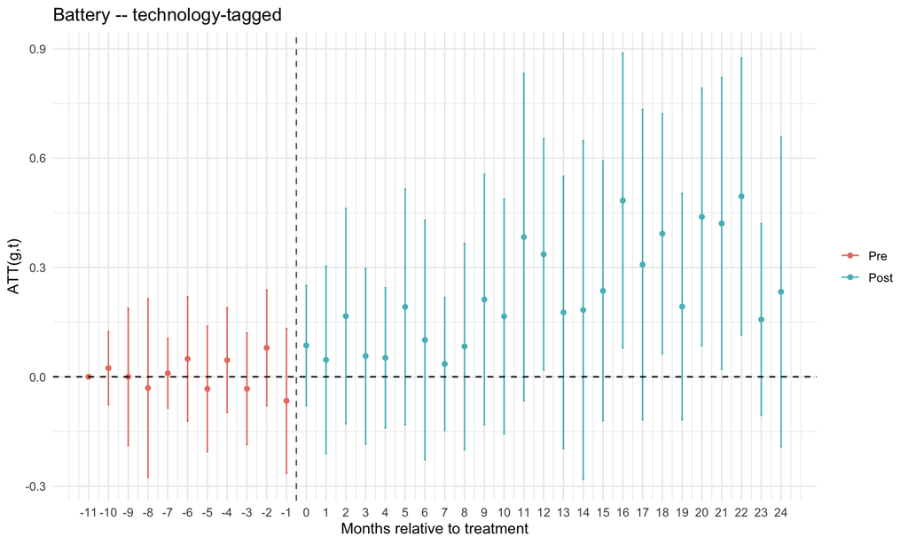

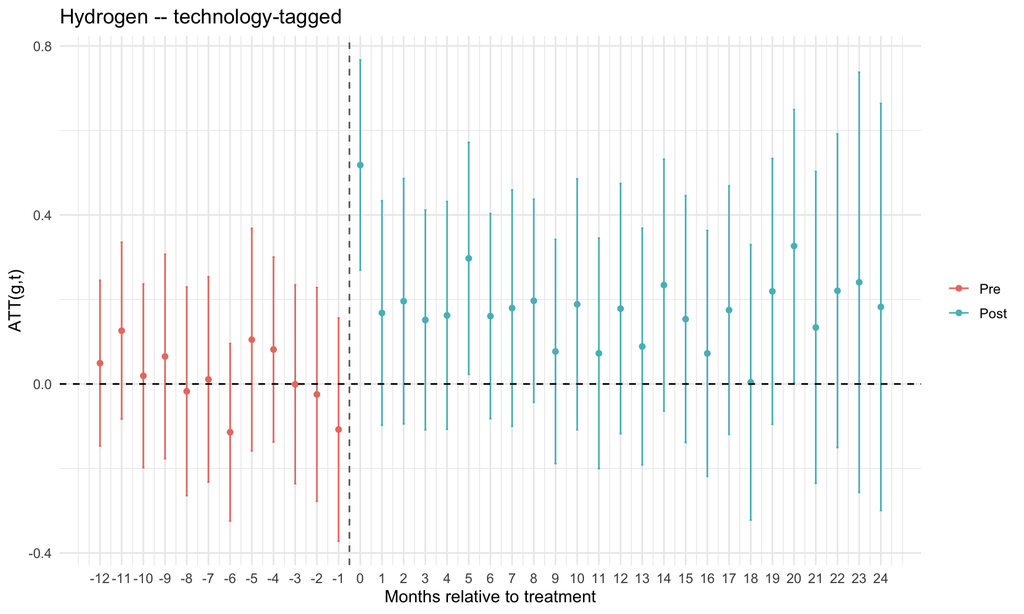

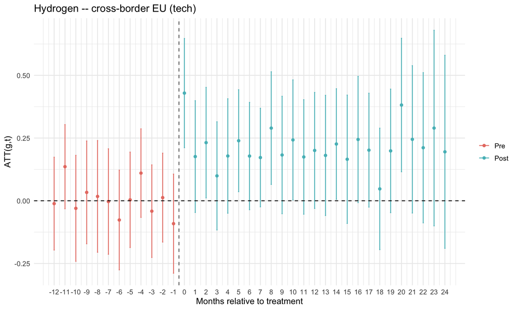

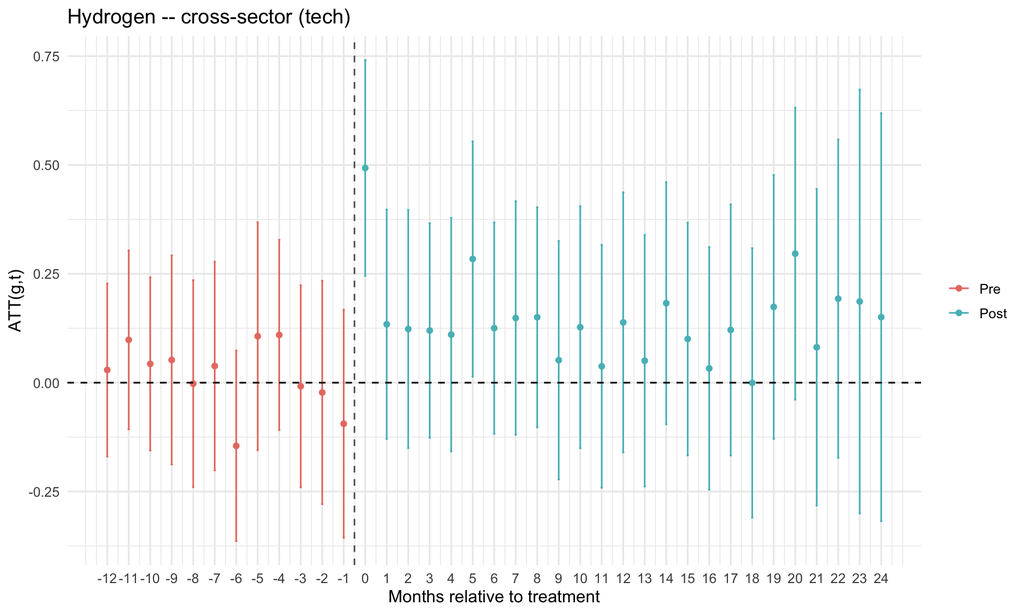

```r
es <- list(
  battery_tech  = plot_cs(agg_dynamic(cs_tech$battery),  "Battery -- technology-tagged"),
  hydrogen_tech = plot_cs(agg_dynamic(cs_tech$hydrogen), "Hydrogen -- technology-tagged"),
  hydrogen_cb   = plot_cs(agg_dynamic(cs_cb$hydrogen),   "Hydrogen -- cross-border EU (tech)"),
  hydrogen_xs   = plot_cs(agg_dynamic(cs_xs$hydrogen),   "Hydrogen -- cross-sector (tech)")
)
for (nm in names(es)) {
  if (!is.null(es[[nm]])) {
    print(es[[nm]])
    ggsave(file.path(out_dir, paste0("es_", nm, ".pdf")),
           es[[nm]], width = 10, height = 6)
  }
}
```

# 4. Summary Table

```r
spec <- list(
  list(cs_tech, "Technology-tagged collaborations", "Primary", "tech_focused"),
  list(cs_cb,   "Cross-border EU collaborations",    "Primary", "cross_border"),
  list(cs_xs,   "Cross-sector collaborations",       "Primary", "cross_sector"),
  list(cs_xs_n1,"Cross-sector collaborations (NACE-1)","Robustness (NACE-1)","cross_sector_nace1"),
  list(cs_neu,  "Non-EU collaborations",             "Placebo",    "non_eu"),
  list(cs_dom,  "Domestic collaborations",           "Placebo",    "domestic"),
  list(cs_ws,   "Within-sector collaborations",      "Placebo",    "within_sector"),
  list(cs_nf,   "Non-funded collaborations",         "Benchmark",  "non_funded"),
  list(cs_xseu, "Cross-sector EU-only collaborations","Primary","cross_sector_eu")
)

att_table <- do.call(rbind, lapply(spec, function(s) {
  cs <- s[[1]]; outcome <- s[[2]]; type <- s[[3]]; key <- s[[4]]
  rbind(
    make_att_row(agg_simple(cs$battery), "Battery", outcome, type,
                 cs$battery, battery_s1, outcome_map[[key]]["battery"]),
    make_att_row(agg_simple(cs$hydrogen), "Hydrogen", outcome, type,
                 cs$hydrogen, hydrogen_s1, outcome_map[[key]]["hydrogen"])
  )
}))

cat("\n=== Tech-tagged ATT Summary (", TIME_UNIT, ") ===\n", sep = "")
```

```
##
## === Tech-tagged ATT Summary (month) ===
```

```r
print(att_table, row.names = FALSE)
```

```
##  Technology                              Outcome                Type TimeUnit
##     Battery     Technology-tagged collaborations             Primary    month
##    Hydrogen     Technology-tagged collaborations             Primary    month
##     Battery       Cross-border EU collaborations             Primary    month
##    Hydrogen       Cross-border EU collaborations             Primary    month
##     Battery          Cross-sector collaborations             Primary    month
##    Hydrogen          Cross-sector collaborations             Primary    month
##     Battery Cross-sector collaborations (NACE-1) Robustness (NACE-1)    month
##    Hydrogen Cross-sector collaborations (NACE-1) Robustness (NACE-1)    month
##     Battery                Non-EU collaborations             Placebo    month
##    Hydrogen                Non-EU collaborations             Placebo    month
##     Battery              Domestic collaborations             Placebo    month
##    Hydrogen              Domestic collaborations             Placebo    month
##     Battery         Within-sector collaborations             Placebo    month
##    Hydrogen         Within-sector collaborations             Placebo    month
##     Battery            Non-funded collaborations           Benchmark    month
##    Hydrogen            Non-funded collaborations           Benchmark    month
##     Battery  Cross-sector EU-only collaborations             Primary    month
##    Hydrogen  Cross-sector EU-only collaborations             Primary    month
##      ATT     SE p_value pretrend_stat pretrend_p_value pretrend_test N_obs
##   0.2911 0.1121   0.009         9.455            0.580          Wald  8280
##   0.1628 0.0798   0.041        12.064            0.441      ES-joint 19080
##   0.1940 0.0867   0.025        16.067            0.139      ES-joint  8280
##   0.1989 0.0656   0.002        13.749            0.317      ES-joint 19080
##   0.2702 0.1018   0.008        12.725            0.312          Wald  8280
##   0.1182 0.0791   0.135        12.936            0.374      ES-joint 19080
##   0.1869 0.0811   0.021         9.953            0.535          Wald  8280
##   0.1249 0.0709   0.078        12.475            0.408      ES-joint 19080
##   0.2220 0.0927   0.017        12.845            0.304          Wald  8280
##   0.2134 0.0580   0.000        11.175            0.514      ES-joint 19080
##   0.1953 0.0577   0.001         8.070            0.707      ES-joint  8280
##   0.0411 0.0685   0.549        16.045            0.189      ES-joint 19080
##   0.1240 0.0595   0.037         2.924            0.992      ES-joint  8280
##   0.1162 0.0567   0.041        27.173            0.007      ES-joint 19080
##  -0.0136 0.1370   0.921        10.550            0.482          Wald  8280
##  -0.0127 0.0620   0.838         8.455            0.749      ES-joint 19080
##   0.2527 0.0941   0.007        12.455            0.330      ES-joint  8280
##   0.1032 0.0742   0.164        16.596            0.165      ES-joint 19080
##  N_units N_treated
##      115        29
##      265        93
##      115        29
##      265        93
##      115        29
##      265        93
##      115        29
##      265        93
##      115        29
##      265        93
##      115        29
##      265        93
##      115        29
##      265        93
##      115        29
##      265        93
##      115        29
##      265        93
```

```r
write.csv(att_table,
          file.path(out_dir, "att_techtagged_table.csv"), row.names = FALSE)
```

```r
# ============================================================
# Export tech-tagged dynamic ATT(e) in long format for notebook 08.
# The es_*.pdf files are ggdid's default style; 08 redraws in house
# style from THIS csv. One row per (technology, outcome, event_time).
# ============================================================

# (technology, outcome-label, cs object) for every outcome we want an ES for.
# Labels MUST match the convention notebook 08 filters on. Adjust the label
# strings here if 08 expects a different separator/spelling.
es_spec <- list(
  list("Battery",  "Technology-tagged collaborations", cs_tech$battery),
  list("Hydrogen", "Technology-tagged collaborations", cs_tech$hydrogen),
  list("Battery",  "Cross-border EU collaborations",   cs_cb$battery),
  list("Hydrogen", "Cross-border EU collaborations",   cs_cb$hydrogen),
  list("Battery",  "Cross-sector collaborations",      cs_xs$battery),
  list("Hydrogen", "Cross-sector collaborations",      cs_xs$hydrogen),
  list("Battery",  "Non-EU collaborations",            cs_neu$battery),
  list("Hydrogen", "Non-EU collaborations",            cs_neu$hydrogen),
  list("Battery",  "Domestic collaborations",          cs_dom$battery),
  list("Hydrogen", "Domestic collaborations",          cs_dom$hydrogen),
  list("Battery",  "Within-sector collaborations",     cs_ws$battery),
  list("Hydrogen", "Within-sector collaborations",     cs_ws$hydrogen),
  list("Battery",  "Non-funded collaborations",        cs_nf$battery),
  list("Hydrogen", "Non-funded collaborations",        cs_nf$hydrogen),
  list("Battery",  "Cross-sector EU-only collaborations", cs_xseu$battery),
  list("Hydrogen", "Cross-sector EU-only collaborations", cs_xseu$hydrogen)
)

# Consortium-size mechanism path: compute its C&S objects HERE so the dynamic
# event study is always exported. Section 10 (which writes consortium_size_att.csv)
# runs AFTER this chunk, so its cs_size does not yet exist on knit -- the old
# guard on exists("cs_size") silently dropped these rows. Estimator is IDENTICAL
# to Section 10: cg_for() control group, no clustering, so the ES matches the ATT.
# Event study uses the ACTIVE-month version (intensive margin), matching the
# headline mechanism in Section 10; falls back to the zero-filled column on old
# panels that predate 05a adding mean_collab_size_active.
SIZE_ES_COL <- if ("mean_collab_size_active" %in% names(battery_s1))
  "mean_collab_size_active" else "mean_collab_size"

if (RUN_CONSORTIUM && "mean_collab_size" %in% names(battery_s1)) {
  cs_size <- list(
    battery  = run_cs(battery_s1,  SIZE_ES_COL,
                      "Battery -- consortium size (mechanism)",
                      control_group = cg_for("battery")),
    hydrogen = run_cs(hydrogen_s1, SIZE_ES_COL,
                      "Hydrogen -- consortium size (mechanism)",
                      control_group = cg_for("hydrogen"))
  )
  es_spec <- c(es_spec, list(
    list("Battery",  "Consortium size (mean firms/collab)", cs_size$battery),
    list("Hydrogen", "Consortium size (mean firms/collab)", cs_size$hydrogen)
  ))
}

es_to_df <- function(tech, outcome, cs_obj) {
  if (is.null(cs_obj)) return(NULL)
  d <- tryCatch(agg_dynamic(cs_obj), error = function(e) NULL)
  if (is.null(d)) return(NULL)
  # Simultaneous band: aggte() is called with cband = TRUE, so crit.val.egt is
  # the uniform critical value over the whole event-time path. Falls back to the
  # pointwise normal value only if the bootstrap did not return one.
  z <- if (!is.null(d$crit.val.egt) && is.finite(d$crit.val.egt))
    d$crit.val.egt else qnorm(0.975)
  data.frame(
    label      = paste(tech, "--", outcome),   # match 08's label convention
    Technology = tech,
    Outcome    = outcome,
    e          = d$egt,
    att        = d$att.egt,
    se         = d$se.egt,
    crit_val   = z,
    ci_lower   = d$att.egt - z * d$se.egt,
    ci_upper   = d$att.egt + z * d$se.egt,
    TimeUnit   = TIME_UNIT,
    stringsAsFactors = FALSE
  )
}

event_study_tt <- do.call(rbind, lapply(es_spec, function(s)
  es_to_df(s[[1]], s[[2]], s[[3]])))

write.csv(event_study_tt,
          file.path(out_dir, "event_study_techtagged.csv"), row.names = FALSE)
cat("\nWrote event_study_techtagged.csv:", nrow(event_study_tt), "rows,",
    length(unique(event_study_tt$label)), "outcome-technology series\n")
```

```
##
## Wrote event_study_techtagged.csv: 584 rows, 16 outcome-technology series
```

```r
print(table(event_study_tt$label))
```

```
##
##       Battery -- Cross-border EU collaborations
##                                              36
##  Battery -- Cross-sector EU-only collaborations
##                                              36
##          Battery -- Cross-sector collaborations
##                                              36
##              Battery -- Domestic collaborations
##                                              36
##                Battery -- Non-EU collaborations
##                                              36
##            Battery -- Non-funded collaborations
##                                              36
##     Battery -- Technology-tagged collaborations
##                                              36
##         Battery -- Within-sector collaborations
##                                              36
##      Hydrogen -- Cross-border EU collaborations
##                                              37
## Hydrogen -- Cross-sector EU-only collaborations
##                                              37
##         Hydrogen -- Cross-sector collaborations
##                                              37
##             Hydrogen -- Domestic collaborations
##                                              37
##               Hydrogen -- Non-EU collaborations
##                                              37
##           Hydrogen -- Non-funded collaborations
##                                              37
##    Hydrogen -- Technology-tagged collaborations
##                                              37
##        Hydrogen -- Within-sector collaborations
##                                              37
```

# 5. Extensive-margin robustness (binary outcome)

When a tech-tagged count is mostly zeros, a `log1p` ATT is dominated by the zero mass and its magnitude is hard to read as an elasticity (Chen & Roth on logs-with-zeros). A linear-probability C&S on the binary “any such tie this period” outcome is an honest complement: the ATT is then a change in the probability of forming that type of tie. Same identification, more interpretable when events are rare.

```r
any_map <- lapply(outcome_map, function(v) sub("^log_collabs", "any_collabs", v))

ext_keys <- c("tech_focused", "cross_border", "cross_sector")  # the ones we care about
ext_rows <- list()
for (key in ext_keys) {
  cb <- run_cs(battery_s1,  any_map[[key]]["battery"],
               paste("Battery S2 -- EXT", key),
               control_group = cg_for("battery"))   # single cohort -> nevertreated
  ch <- run_cs(hydrogen_s1, any_map[[key]]["hydrogen"],
               paste("Hydrogen S2 -- EXT", key),
               control_group = cg_for("hydrogen"))
  ext_rows[[length(ext_rows) + 1]] <-
    make_att_row(agg_simple(cb), "Battery", paste0("[ext] ", key), "Ext. margin",
                 cb, battery_s1, any_map[[key]]["battery"])
  ext_rows[[length(ext_rows) + 1]] <-
    make_att_row(agg_simple(ch), "Hydrogen", paste0("[ext] ", key), "Ext. margin",
                 ch, hydrogen_s1, any_map[[key]]["hydrogen"])
}
```

```
##
## === C&S: Battery S2 -- EXT tech_focused ( any_collabs_battery ) ===
##
## Call:
## att_gt(yname = yname, tname = "period", idname = "firm_id", gname = "g_period",
##     data = df, panel = TRUE, control_group = control_group, anticipation = 0,
##     bstrap = TRUE, biters = BITERS, clustervars = clustervars,
##     pl = TRUE)
##
## Reference: Callaway, Brantly and Pedro H.C. Sant'Anna.  "Difference-in-Differences with Multiple Time Periods." Journal of Econometrics, Vol. 225, No. 2, pp. 200-230, 2021. <https://doi.org/10.1016/j.jeconom.2020.12.001>, <https://arxiv.org/abs/1803.09015>
##
## Group-Time Average Treatment Effects:
##  Group Time ATT(g,t) Std. Error [95% Simult.  Conf. Band]
##     13    2  -0.0345     0.0494       -0.1771      0.1082
##     13    3   0.0690     0.0423       -0.0533      0.1912
```

[output cut: 78 more lines]

```
##
## Call:
## att_gt(yname = yname, tname = "period", idname = "firm_id", gname = "g_period",
##     data = df, panel = TRUE, control_group = control_group, anticipation = 0,
##     bstrap = TRUE, biters = BITERS, clustervars = clustervars,
##     pl = TRUE)
##
## Reference: Callaway, Brantly and Pedro H.C. Sant'Anna.  "Difference-in-Differences with Multiple Time Periods." Journal of Econometrics, Vol. 225, No. 2, pp. 200-230, 2021. <https://doi.org/10.1016/j.jeconom.2020.12.001>, <https://arxiv.org/abs/1803.09015>
##
## Group-Time Average Treatment Effects:
##  Group Time ATT(g,t) Std. Error [95% Simult.  Conf. Band]
##     31    2  -0.1054     0.0708       -0.3327      0.1220
##     31    3   0.0487     0.0693       -0.1740      0.2714
##     31    4   0.0138     0.0679       -0.2043      0.2319
##     31    5  -0.0116     0.0172       -0.0670      0.0438
```

[output cut: 288 more lines]

```
##
## Call:
## att_gt(yname = yname, tname = "period", idname = "firm_id", gname = "g_period",
##     data = df, panel = TRUE, control_group = control_group, anticipation = 0,
##     bstrap = TRUE, biters = BITERS, clustervars = clustervars,
##     pl = TRUE)
##
## Reference: Callaway, Brantly and Pedro H.C. Sant'Anna.  "Difference-in-Differences with Multiple Time Periods." Journal of Econometrics, Vol. 225, No. 2, pp. 200-230, 2021. <https://doi.org/10.1016/j.jeconom.2020.12.001>, <https://arxiv.org/abs/1803.09015>
##
## Group-Time Average Treatment Effects:
##  Group Time ATT(g,t) Std. Error [95% Simult.  Conf. Band]
##     13    2   0.0345     0.0494       -0.1058      0.1748
##     13    3  -0.0345     0.0494       -0.1748      0.1058
##     13    4   0.0690     0.0458       -0.0613      0.1992
##     13    5  -0.0345     0.0547       -0.1898      0.1208
```

[output cut: 75 more lines]

```
##
## Call:
## att_gt(yname = yname, tname = "period", idname = "firm_id", gname = "g_period",
##     data = df, panel = TRUE, control_group = control_group, anticipation = 0,
##     bstrap = TRUE, biters = BITERS, clustervars = clustervars,
##     pl = TRUE)
##
## Reference: Callaway, Brantly and Pedro H.C. Sant'Anna.  "Difference-in-Differences with Multiple Time Periods." Journal of Econometrics, Vol. 225, No. 2, pp. 200-230, 2021. <https://doi.org/10.1016/j.jeconom.2020.12.001>, <https://arxiv.org/abs/1803.09015>
##
## Group-Time Average Treatment Effects:
##  Group Time ATT(g,t) Std. Error [95% Simult.  Conf. Band]
##     31    2  -0.0312     0.0550       -0.2097      0.1472
##     31    3   0.0312     0.0550       -0.1472      0.2097
##     31    4  -0.0371     0.0575       -0.2239      0.1498
##     31    5   0.0254     0.0451       -0.1209      0.1718
```

[output cut: 379 more lines]

```
##
## Call:
## att_gt(yname = yname, tname = "period", idname = "firm_id", gname = "g_period",
##     data = df, panel = TRUE, control_group = control_group, anticipation = 0,
##     bstrap = TRUE, biters = BITERS, clustervars = clustervars,
##     pl = TRUE)
##
## Reference: Callaway, Brantly and Pedro H.C. Sant'Anna.  "Difference-in-Differences with Multiple Time Periods." Journal of Econometrics, Vol. 225, No. 2, pp. 200-230, 2021. <https://doi.org/10.1016/j.jeconom.2020.12.001>, <https://arxiv.org/abs/1803.09015>
##
## Group-Time Average Treatment Effects:
##  Group Time ATT(g,t) Std. Error [95% Simult.  Conf. Band]
##     31    2  -0.0996     0.0708       -0.3293      0.1302
##     31    3   0.0429     0.0681       -0.1779      0.2636
##     31    4  -0.0174     0.0818       -0.2827      0.2478
##     31    5   0.0196     0.0453       -0.1273      0.1665
```

[output cut: 286 more lines]

```r
ext_table <- do.call(rbind, ext_rows)
cat("\n=== Extensive-margin ATT (", TIME_UNIT, ") ===\n", sep = "")
```

```
##
## === Extensive-margin ATT (month) ===
```

```r
print(ext_table, row.names = FALSE)
```

```
##  Technology            Outcome        Type TimeUnit    ATT     SE p_value
##     Battery [ext] tech_focused Ext. margin    month 0.1437 0.0696   0.039
##    Hydrogen [ext] tech_focused Ext. margin    month 0.0778 0.0451   0.084
##     Battery [ext] cross_border Ext. margin    month 0.1245 0.0706   0.078
##    Hydrogen [ext] cross_border Ext. margin    month 0.1221 0.0480   0.011
##     Battery [ext] cross_sector Ext. margin    month 0.1213 0.0711   0.088
##    Hydrogen [ext] cross_sector Ext. margin    month 0.0543 0.0459   0.237
##  pretrend_stat pretrend_p_value pretrend_test N_obs N_units N_treated
##         12.115            0.355          Wald  8280     115        29
##         12.223            0.428      ES-joint 19080     265        93
##         15.149            0.176      ES-joint  8280     115        29
##         17.827            0.121      ES-joint 19080     265        93
##         11.026            0.356          Wald  8280     115        29
##         11.353            0.499      ES-joint 19080     265        93
```

```r
write.csv(ext_table,
          file.path(out_dir, "att_extensive_margin.csv"), row.names = FALSE)
```

# 6. Robustness (technology-tagged)

The primary spec (section 4) is the tighter-balance matched sample (`battery_s1` = 1:3, `hydrogen_s1` = cal20_r2) with never-treated controls + firm-level clustering. Robustness reuses `run_cs()` + `outcome_map`, the contiguous period index and the firm-quarter aggregation (inheriting the `TIME_UNIT` toggle) and reports two checks: (a) **larger control group** – the SAME never-treated + firm-clustered estimator re-run on the higher-ratio power matched sample (`battery_s2` = 1:7, `hydrogen_s2` = cal15_r3); and (b) **not-yet-treated controls** as one shown alternative (hydrogen only – battery is a single cohort with no not-yet-treated units), so the reader sees the primary never-treated choice does not drive the results. The table is parallel to section 4.

```r
# Outcomes to re-run -- mirrors the section-4 spec list (the optional
# cross_sector_eu outcome is skipped here).
rob_spec <- list(
  list("tech_focused",  "Technology-tagged collaborations"),
  list("cross_border",  "Cross-border EU collaborations"),
  list("cross_sector",  "Cross-sector collaborations"),
  list("cross_sector_nace1", "Cross-sector collaborations (NACE-1)"),
  list("non_eu",        "Non-EU collaborations"),
  list("domestic",      "Domestic collaborations"),
  list("within_sector", "Within-sector collaborations"),
  list("non_funded",    "Non-funded collaborations")
)

# One robustness ATT row: pick the tech-tagged column from outcome_map, run C&S
# with the requested variant, return a section-4-parallel row (NULL-safe).
rob_one <- function(df, key, technology, outcome, variant,
                    control_group = NULL, clustervars = NULL) {
  # Default to the primary control group (never-treated, via cg_for). The
  # "Not-yet-treated controls" variant passes control_group explicitly to override.
  if (is.null(control_group)) control_group <- cg_for(technology)
  yn <- outcome_map[[key]][tolower(technology)]
  cs <- run_cs(df, yn,
               label         = paste(technology, "--", outcome, "--", variant),
               control_group = control_group,
               clustervars   = clustervars)
  make_att_row(agg_simple(cs), technology, outcome, variant, cs, df, yn)
}

rob_rows <- list()
for (s in rob_spec) {
  key <- s[[1]]; oc <- s[[2]]
  rob_rows <- c(rob_rows, list(
    # (a) larger control group (power spec, S2): SAME primary estimator
    #     (never-treated + firm clustering) on the higher-ratio matched sample
    rob_one(battery_s2,  key, "Battery",  oc, "Larger control group", clustervars = "firm_id"),
    rob_one(hydrogen_s2, key, "Hydrogen", oc, "Larger control group", clustervars = "firm_id"),
    # (b) not-yet-treated controls (hydrogen only; battery is a single cohort with
    #     no not-yet-treated units) -- shows the never-treated primary choice does
    #     not drive results
    rob_one(hydrogen_s1, key, "Hydrogen", oc, "Not-yet-treated controls",
            control_group = "notyettreated", clustervars = "firm_id")
  ))
}
```

```
##
## === C&S: Battery -- Technology-tagged collaborations -- Larger control group ( log_collabs_battery ) ===
##
## Call:
## att_gt(yname = yname, tname = "period", idname = "firm_id", gname = "g_period",
##     data = df, panel = TRUE, control_group = control_group, anticipation = 0,
##     bstrap = TRUE, biters = BITERS, clustervars = clustervars,
##     pl = TRUE)
##
## Reference: Callaway, Brantly and Pedro H.C. Sant'Anna.  "Difference-in-Differences with Multiple Time Periods." Journal of Econometrics, Vol. 225, No. 2, pp. 200-230, 2021. <https://doi.org/10.1016/j.jeconom.2020.12.001>, <https://arxiv.org/abs/1803.09015>
##
## Group-Time Average Treatment Effects:
##  Group Time ATT(g,t) Std. Error [95% Simult.  Conf. Band]
##     13    2  -0.0036     0.0650       -0.1825      0.1754
##     13    3   0.0239     0.0407       -0.0882      0.1360
```

[output cut: 78 more lines]

```
##
## Call:
## att_gt(yname = yname, tname = "period", idname = "firm_id", gname = "g_period",
##     data = df, panel = TRUE, control_group = control_group, anticipation = 0,
##     bstrap = TRUE, biters = BITERS, clustervars = clustervars,
##     pl = TRUE)
##
## Reference: Callaway, Brantly and Pedro H.C. Sant'Anna.  "Difference-in-Differences with Multiple Time Periods." Journal of Econometrics, Vol. 225, No. 2, pp. 200-230, 2021. <https://doi.org/10.1016/j.jeconom.2020.12.001>, <https://arxiv.org/abs/1803.09015>
##
## Group-Time Average Treatment Effects:
##  Group Time ATT(g,t) Std. Error [95% Simult.  Conf. Band]
##     31    2  -0.1254     0.0949       -0.4243      0.1734
##     31    3   0.0049     0.0579       -0.1774      0.1871
##     31    4   0.0688     0.0989       -0.2427      0.3803
##     31    5  -0.0209     0.0500       -0.1783      0.1365
```

[output cut: 288 more lines]

```
##
## Call:
## att_gt(yname = yname, tname = "period", idname = "firm_id", gname = "g_period",
##     data = df, panel = TRUE, control_group = control_group, anticipation = 0,
##     bstrap = TRUE, biters = BITERS, clustervars = clustervars,
##     pl = TRUE)
##
## Reference: Callaway, Brantly and Pedro H.C. Sant'Anna.  "Difference-in-Differences with Multiple Time Periods." Journal of Econometrics, Vol. 225, No. 2, pp. 200-230, 2021. <https://doi.org/10.1016/j.jeconom.2020.12.001>, <https://arxiv.org/abs/1803.09015>
##
## Group-Time Average Treatment Effects:
##  Group Time ATT(g,t) Std. Error [95% Simult.  Conf. Band]
##     31    2  -0.1356     0.0964       -0.4427      0.1714
##     31    3   0.0231     0.0631       -0.1780      0.2242
##     31    4   0.0497     0.0978       -0.2619      0.3612
##     31    5  -0.0146     0.0503       -0.1749      0.1458
```

[output cut: 288 more lines]

```
##
## Call:
## att_gt(yname = yname, tname = "period", idname = "firm_id", gname = "g_period",
##     data = df, panel = TRUE, control_group = control_group, anticipation = 0,
##     bstrap = TRUE, biters = BITERS, clustervars = clustervars,
##     pl = TRUE)
##
## Reference: Callaway, Brantly and Pedro H.C. Sant'Anna.  "Difference-in-Differences with Multiple Time Periods." Journal of Econometrics, Vol. 225, No. 2, pp. 200-230, 2021. <https://doi.org/10.1016/j.jeconom.2020.12.001>, <https://arxiv.org/abs/1803.09015>
##
## Group-Time Average Treatment Effects:
##  Group Time ATT(g,t) Std. Error [95% Simult.  Conf. Band]
##     13    2   0.0239     0.0342       -0.0672      0.1150
##     13    3  -0.0239     0.0342       -0.1150      0.0672
##     13    4   0.0336     0.0344       -0.0580      0.1251
##     13    5  -0.0028     0.0570       -0.1547      0.1491
```

[output cut: 75 more lines]

```
##
## Call:
## att_gt(yname = yname, tname = "period", idname = "firm_id", gname = "g_period",
##     data = df, panel = TRUE, control_group = control_group, anticipation = 0,
##     bstrap = TRUE, biters = BITERS, clustervars = clustervars,
##     pl = TRUE)
##
## Reference: Callaway, Brantly and Pedro H.C. Sant'Anna.  "Difference-in-Differences with Multiple Time Periods." Journal of Econometrics, Vol. 225, No. 2, pp. 200-230, 2021. <https://doi.org/10.1016/j.jeconom.2020.12.001>, <https://arxiv.org/abs/1803.09015>
##
## Group-Time Average Treatment Effects:
##  Group Time ATT(g,t) Std. Error [95% Simult.  Conf. Band]
##     31    2  -0.0752     0.0867       -0.3376      0.1872
##     31    3   0.0002     0.0506       -0.1531      0.1535
##     31    4   0.0195     0.1004       -0.2845      0.3235
##     31    5  -0.0211     0.0678       -0.2263      0.1841
```

[output cut: 288 more lines]

```
##
## Call:
## att_gt(yname = yname, tname = "period", idname = "firm_id", gname = "g_period",
##     data = df, panel = TRUE, control_group = control_group, anticipation = 0,
##     bstrap = TRUE, biters = BITERS, clustervars = clustervars,
##     pl = TRUE)
##
## Reference: Callaway, Brantly and Pedro H.C. Sant'Anna.  "Difference-in-Differences with Multiple Time Periods." Journal of Econometrics, Vol. 225, No. 2, pp. 200-230, 2021. <https://doi.org/10.1016/j.jeconom.2020.12.001>, <https://arxiv.org/abs/1803.09015>
##
## Group-Time Average Treatment Effects:
##  Group Time ATT(g,t) Std. Error [95% Simult.  Conf. Band]
##     31    2  -0.0726     0.0877       -0.3438      0.1987
##     31    3   0.0120     0.0512       -0.1463      0.1703
##     31    4   0.0101     0.1006       -0.3009      0.3212
##     31    5  -0.0255     0.0699       -0.2416      0.1906
```

[output cut: 379 more lines]

```
##
## Call:
## att_gt(yname = yname, tname = "period", idname = "firm_id", gname = "g_period",
##     data = df, panel = TRUE, control_group = control_group, anticipation = 0,
##     bstrap = TRUE, biters = BITERS, clustervars = clustervars,
##     pl = TRUE)
##
## Reference: Callaway, Brantly and Pedro H.C. Sant'Anna.  "Difference-in-Differences with Multiple Time Periods." Journal of Econometrics, Vol. 225, No. 2, pp. 200-230, 2021. <https://doi.org/10.1016/j.jeconom.2020.12.001>, <https://arxiv.org/abs/1803.09015>
##
## Group-Time Average Treatment Effects:
##  Group Time ATT(g,t) Std. Error [95% Simult.  Conf. Band]
##     31    2  -0.1199     0.0941       -0.4196      0.1798
##     31    3  -0.0007     0.0583       -0.1864      0.1851
##     31    4  -0.0114     0.0489       -0.1670      0.1443
##     31    5   0.0501     0.0323       -0.0528      0.1529
```

[output cut: 288 more lines]

```
##
## Call:
## att_gt(yname = yname, tname = "period", idname = "firm_id", gname = "g_period",
##     data = df, panel = TRUE, control_group = control_group, anticipation = 0,
##     bstrap = TRUE, biters = BITERS, clustervars = clustervars,
##     pl = TRUE)
##
## Reference: Callaway, Brantly and Pedro H.C. Sant'Anna.  "Difference-in-Differences with Multiple Time Periods." Journal of Econometrics, Vol. 225, No. 2, pp. 200-230, 2021. <https://doi.org/10.1016/j.jeconom.2020.12.001>, <https://arxiv.org/abs/1803.09015>
##
## Group-Time Average Treatment Effects:
##  Group Time ATT(g,t) Std. Error [95% Simult.  Conf. Band]
##     31    2  -0.1326     0.0965       -0.4401      0.1748
##     31    3   0.0201     0.0614       -0.1756      0.2159
##     31    4  -0.0277     0.0512       -0.1910      0.1355
##     31    5   0.0527     0.0359       -0.0615      0.1669
```

[output cut: 379 more lines]

```
##
## Call:
## att_gt(yname = yname, tname = "period", idname = "firm_id", gname = "g_period",
##     data = df, panel = TRUE, control_group = control_group, anticipation = 0,
##     bstrap = TRUE, biters = BITERS, clustervars = clustervars,
##     pl = TRUE)
##
## Reference: Callaway, Brantly and Pedro H.C. Sant'Anna.  "Difference-in-Differences with Multiple Time Periods." Journal of Econometrics, Vol. 225, No. 2, pp. 200-230, 2021. <https://doi.org/10.1016/j.jeconom.2020.12.001>, <https://arxiv.org/abs/1803.09015>
##
## Group-Time Average Treatment Effects:
##  Group Time ATT(g,t) Std. Error [95% Simult.  Conf. Band]
##     31    2  -0.0766     0.1018       -0.4166      0.2634
##     31    3   0.0046     0.0569       -0.1854      0.1946
##     31    4  -0.0563     0.0355       -0.1747      0.0621
##     31    5   0.0033     0.0150       -0.0468      0.0535
```

[output cut: 288 more lines]

```
##
## Call:
## att_gt(yname = yname, tname = "period", idname = "firm_id", gname = "g_period",
##     data = df, panel = TRUE, control_group = control_group, anticipation = 0,
##     bstrap = TRUE, biters = BITERS, clustervars = clustervars,
##     pl = TRUE)
##
## Reference: Callaway, Brantly and Pedro H.C. Sant'Anna.  "Difference-in-Differences with Multiple Time Periods." Journal of Econometrics, Vol. 225, No. 2, pp. 200-230, 2021. <https://doi.org/10.1016/j.jeconom.2020.12.001>, <https://arxiv.org/abs/1803.09015>
##
## Group-Time Average Treatment Effects:
##  Group Time ATT(g,t) Std. Error [95% Simult.  Conf. Band]
##     31    2  -0.0909     0.1014       -0.4110      0.2292
##     31    3   0.0244     0.0606       -0.1669      0.2156
##     31    4  -0.0659     0.0375       -0.1843      0.0525
##     31    5   0.0028     0.0204       -0.0617      0.0674
```

[output cut: 379 more lines]

```
##
## Call:
## att_gt(yname = yname, tname = "period", idname = "firm_id", gname = "g_period",
##     data = df, panel = TRUE, control_group = control_group, anticipation = 0,
##     bstrap = TRUE, biters = BITERS, clustervars = clustervars,
##     pl = TRUE)
##
## Reference: Callaway, Brantly and Pedro H.C. Sant'Anna.  "Difference-in-Differences with Multiple Time Periods." Journal of Econometrics, Vol. 225, No. 2, pp. 200-230, 2021. <https://doi.org/10.1016/j.jeconom.2020.12.001>, <https://arxiv.org/abs/1803.09015>
##
## Group-Time Average Treatment Effects:
##  Group Time ATT(g,t) Std. Error [95% Simult.  Conf. Band]
##     31    2  -0.0948     0.0829       -0.3495      0.1599
##     31    3   0.0282     0.0501       -0.1259      0.1822
##     31    4  -0.0488     0.0327       -0.1494      0.0517
##     31    5  -0.0196     0.0310       -0.1149      0.0757
```

[output cut: 288 more lines]

```
##
## Call:
## att_gt(yname = yname, tname = "period", idname = "firm_id", gname = "g_period",
##     data = df, panel = TRUE, control_group = control_group, anticipation = 0,
##     bstrap = TRUE, biters = BITERS, clustervars = clustervars,
##     pl = TRUE)
##
## Reference: Callaway, Brantly and Pedro H.C. Sant'Anna.  "Difference-in-Differences with Multiple Time Periods." Journal of Econometrics, Vol. 225, No. 2, pp. 200-230, 2021. <https://doi.org/10.1016/j.jeconom.2020.12.001>, <https://arxiv.org/abs/1803.09015>
##
## Group-Time Average Treatment Effects:
##  Group Time ATT(g,t) Std. Error [95% Simult.  Conf. Band]
##     31    2  -0.1045     0.0841       -0.3671      0.1581
##     31    3   0.0270     0.0486       -0.1245      0.1785
##     31    4  -0.0535     0.0350       -0.1628      0.0559
##     31    5  -0.0098     0.0317       -0.1086      0.0891
```

[output cut: 379 more lines]

```
##
## Call:
## att_gt(yname = yname, tname = "period", idname = "firm_id", gname = "g_period",
##     data = df, panel = TRUE, control_group = control_group, anticipation = 0,
##     bstrap = TRUE, biters = BITERS, clustervars = clustervars,
##     pl = TRUE)
##
## Reference: Callaway, Brantly and Pedro H.C. Sant'Anna.  "Difference-in-Differences with Multiple Time Periods." Journal of Econometrics, Vol. 225, No. 2, pp. 200-230, 2021. <https://doi.org/10.1016/j.jeconom.2020.12.001>, <https://arxiv.org/abs/1803.09015>
##
## Group-Time Average Treatment Effects:
##  Group Time ATT(g,t) Std. Error [95% Simult.  Conf. Band]
##     31    2  -0.0461     0.0521       -0.2064      0.1142
##     31    3   0.0028     0.0208       -0.0614      0.0669
##     31    4   0.0269     0.0506       -0.1290      0.1827
##     31    5   0.0291     0.0315       -0.0678      0.1260
```

[output cut: 288 more lines]

```
##
## Call:
## att_gt(yname = yname, tname = "period", idname = "firm_id", gname = "g_period",
##     data = df, panel = TRUE, control_group = control_group, anticipation = 0,
##     bstrap = TRUE, biters = BITERS, clustervars = clustervars,
##     pl = TRUE)
##
## Reference: Callaway, Brantly and Pedro H.C. Sant'Anna.  "Difference-in-Differences with Multiple Time Periods." Journal of Econometrics, Vol. 225, No. 2, pp. 200-230, 2021. <https://doi.org/10.1016/j.jeconom.2020.12.001>, <https://arxiv.org/abs/1803.09015>
##
## Group-Time Average Treatment Effects:
##  Group Time ATT(g,t) Std. Error [95% Simult.  Conf. Band]
##     31    2  -0.0617     0.0495       -0.2153      0.0919
##     31    3   0.0226     0.0365       -0.0905      0.1356
##     31    4   0.0160     0.0527       -0.1475      0.1794
##     31    5   0.0259     0.0334       -0.0778      0.1296
```

[output cut: 379 more lines]

```
##
## Call:
## att_gt(yname = yname, tname = "period", idname = "firm_id", gname = "g_period",
##     data = df, panel = TRUE, control_group = control_group, anticipation = 0,
##     bstrap = TRUE, biters = BITERS, clustervars = clustervars,
##     pl = TRUE)
##
## Reference: Callaway, Brantly and Pedro H.C. Sant'Anna.  "Difference-in-Differences with Multiple Time Periods." Journal of Econometrics, Vol. 225, No. 2, pp. 200-230, 2021. <https://doi.org/10.1016/j.jeconom.2020.12.001>, <https://arxiv.org/abs/1803.09015>
##
## Group-Time Average Treatment Effects:
##  Group Time ATT(g,t) Std. Error [95% Simult.  Conf. Band]
##     31    2  -0.0978     0.0781       -0.3324      0.1367
##     31    3   0.0145     0.0377       -0.0986      0.1276
##     31    4   0.0558     0.0998       -0.2438      0.3554
##     31    5  -0.0447     0.0675       -0.2474      0.1579
```

[output cut: 288 more lines]

```
##
## Call:
## att_gt(yname = yname, tname = "period", idname = "firm_id", gname = "g_period",
##     data = df, panel = TRUE, control_group = control_group, anticipation = 0,
##     bstrap = TRUE, biters = BITERS, clustervars = clustervars,
##     pl = TRUE)
##
## Reference: Callaway, Brantly and Pedro H.C. Sant'Anna.  "Difference-in-Differences with Multiple Time Periods." Journal of Econometrics, Vol. 225, No. 2, pp. 200-230, 2021. <https://doi.org/10.1016/j.jeconom.2020.12.001>, <https://arxiv.org/abs/1803.09015>
##
## Group-Time Average Treatment Effects:
##  Group Time ATT(g,t) Std. Error [95% Simult.  Conf. Band]
##     31    2  -0.0927     0.0803       -0.3366      0.1512
##     31    3   0.0175     0.0414       -0.1084      0.1433
##     31    4   0.0542     0.0992       -0.2473      0.3557
##     31    5  -0.0475     0.0675       -0.2525      0.1575
```

[output cut: 379 more lines]

```
##
## Call:
## att_gt(yname = yname, tname = "period", idname = "firm_id", gname = "g_period",
##     data = df, panel = TRUE, control_group = control_group, anticipation = 0,
##     bstrap = TRUE, biters = BITERS, clustervars = clustervars,
##     pl = TRUE)
##
## Reference: Callaway, Brantly and Pedro H.C. Sant'Anna.  "Difference-in-Differences with Multiple Time Periods." Journal of Econometrics, Vol. 225, No. 2, pp. 200-230, 2021. <https://doi.org/10.1016/j.jeconom.2020.12.001>, <https://arxiv.org/abs/1803.09015>
##
## Group-Time Average Treatment Effects:
##  Group Time ATT(g,t) Std. Error [95% Simult.  Conf. Band]
##     31    2  -0.0776     0.0539       -0.2439      0.0887
##     31    3   0.0657     0.0665       -0.1396      0.2709
##     31    4  -0.0802     0.0671       -0.2873      0.1268
##     31    5   0.0430     0.0504       -0.1125      0.1984
```

[output cut: 288 more lines]

```
##
## Call:
## att_gt(yname = yname, tname = "period", idname = "firm_id", gname = "g_period",
##     data = df, panel = TRUE, control_group = control_group, anticipation = 0,
##     bstrap = TRUE, biters = BITERS, clustervars = clustervars,
##     pl = TRUE)
##
## Reference: Callaway, Brantly and Pedro H.C. Sant'Anna.  "Difference-in-Differences with Multiple Time Periods." Journal of Econometrics, Vol. 225, No. 2, pp. 200-230, 2021. <https://doi.org/10.1016/j.jeconom.2020.12.001>, <https://arxiv.org/abs/1803.09015>
##
## Group-Time Average Treatment Effects:
##  Group Time ATT(g,t) Std. Error [95% Simult.  Conf. Band]
##     31    2  -0.0598     0.0553       -0.2328      0.1132
##     31    3   0.0638     0.0700       -0.1551      0.2827
##     31    4  -0.0805     0.0693       -0.2973      0.1363
##     31    5   0.0578     0.0512       -0.1025      0.2180
```

[output cut: 286 more lines]

```r
rob_table <- do.call(rbind, rob_rows)

cat("\n=== Robustness checks (tech-tagged,", TIME_UNIT, ") ===\n", sep = "")
```

```
##
## === Robustness checks (tech-tagged,month) ===
```

```r
print(rob_table, row.names = FALSE)
```

```
##  Technology                              Outcome                     Type
##     Battery     Technology-tagged collaborations     Larger control group
##    Hydrogen     Technology-tagged collaborations     Larger control group
##    Hydrogen     Technology-tagged collaborations Not-yet-treated controls
##     Battery       Cross-border EU collaborations     Larger control group
##    Hydrogen       Cross-border EU collaborations     Larger control group
##    Hydrogen       Cross-border EU collaborations Not-yet-treated controls
##     Battery          Cross-sector collaborations     Larger control group
##    Hydrogen          Cross-sector collaborations     Larger control group
##    Hydrogen          Cross-sector collaborations Not-yet-treated controls
##     Battery Cross-sector collaborations (NACE-1)     Larger control group
##    Hydrogen Cross-sector collaborations (NACE-1)     Larger control group
##    Hydrogen Cross-sector collaborations (NACE-1) Not-yet-treated controls
##     Battery                Non-EU collaborations     Larger control group
##    Hydrogen                Non-EU collaborations     Larger control group
##    Hydrogen                Non-EU collaborations Not-yet-treated controls
##     Battery              Domestic collaborations     Larger control group
##    Hydrogen              Domestic collaborations     Larger control group
##    Hydrogen              Domestic collaborations Not-yet-treated controls
##     Battery         Within-sector collaborations     Larger control group
##    Hydrogen         Within-sector collaborations     Larger control group
##    Hydrogen         Within-sector collaborations Not-yet-treated controls
##     Battery            Non-funded collaborations     Larger control group
##    Hydrogen            Non-funded collaborations     Larger control group
##    Hydrogen            Non-funded collaborations Not-yet-treated controls
##  TimeUnit     ATT     SE p_value pretrend_stat pretrend_p_value pretrend_test
##     month  0.2755 0.1122   0.014        12.114            0.355          Wald
##     month  0.1368 0.0815   0.093        10.712            0.554      ES-joint
##     month  0.1461 0.0841   0.082        12.475            0.408      ES-joint
##     month  0.1885 0.0865   0.029        15.569            0.158      ES-joint
##     month  0.1818 0.0656   0.006        13.500            0.334      ES-joint
##     month  0.1884 0.0646   0.004        16.173            0.183      ES-joint
##     month  0.2586 0.1045   0.013        12.663            0.316          Wald
##     month  0.0925 0.0776   0.233        11.601            0.478      ES-joint
##     month  0.1027 0.0799   0.199        13.612            0.326      ES-joint
##     month  0.1773 0.0804   0.027        15.051            0.180          Wald
##     month  0.1027 0.0693   0.138        10.994            0.529      ES-joint
##     month  0.1097 0.0724   0.130        11.524            0.485      ES-joint
##     month  0.2083 0.0935   0.026        12.818            0.305          Wald
##     month  0.1880 0.0573   0.001         9.463            0.663      ES-joint
```

[output cut: 20 more lines]

```
##  16128     224        29
##  24624     342        91
##  19080     265        93
##  16128     224        29
##  24624     342        91
##  19080     265        93
##  16128     224        29
##  24624     342        91
##  19080     265        93
##  16128     224        29
##  24624     342        91
##  19080     265        93
##  16128     224        29
##  24624     342        91
##  19080     265        93
```

```r
write.csv(rob_table,
          file.path(out_dir, "robustness_techtagged_table.csv"), row.names = FALSE)
```

# 7. Rosenbaum Bounds (technology-tagged)

```r
run_rosenbaum <- function(matched_firms_path, cs_panel_path,
                           outcome_col = "n_collabs_battery",
                           gamma_max   = 3.0,
                           gamma_inc   = 0.1,
                           label       = "") {

  cat("\n=== Rosenbaum Bounds:", label, "===\n")

  firms <- read.csv(matched_firms_path, stringsAsFactors = FALSE)
  panel <- read.csv(cs_panel_path,      stringsAsFactors = FALSE)
  panel$month <- as.Date(panel$month)

  g_lookup <- panel %>%
    filter(is_treated == 1) %>%
    distinct(Linkedin_name, matched_to, g) %>%
    rename(g_treated = g)

  panel_sym <- panel %>%
    left_join(
      g_lookup %>% select(matched_to, g_treated),
      by = "matched_to"
    ) %>%
    mutate(
      g_use  = ifelse(is_treated == 1, g, g_treated),
      g_date = as.Date(g_use),
      post   = !is.na(g_date) & month >= g_date
    ) %>%
    mutate(y = log1p(.data[[outcome_col]])) %>%
    group_by(Linkedin_name) %>%
    # DiD contrast, not a post-treatment level: each firm's own post-minus-pre
    # change. Pairing these changes makes the Rosenbaum null correspond to the
    # difference-in-differences estimand rather than to a level difference.
    summarise(y_mean = mean(y[post], na.rm = TRUE) - mean(y[!post], na.rm = TRUE),
              .groups = "drop") %>%
    filter(is.finite(y_mean))

  firms <- firms %>%
    left_join(panel_sym, by = "Linkedin_name")

  treated <- firms %>%
    filter(is_treated == 1) %>%
    select(matched_to, Linkedin_name, y_treated = y_mean) %>%
    rename(treated_name = Linkedin_name)

  controls_agg <- firms %>%
    filter(is_control == 1) %>%
    group_by(matched_to) %>%
    summarise(y_control = mean(y_mean, na.rm = TRUE), .groups = "drop")

  pairs <- treated %>%
    left_join(controls_agg, by = "matched_to") %>%
    filter(!is.na(y_treated), !is.na(y_control))

  cat(sprintf("  Valid matched pairs: %d\n", nrow(pairs)))
  cat(sprintf("  Mean treated: %.3f | Mean control: %.3f\n",
              mean(pairs$y_treated), mean(pairs$y_control)))

  cat("\n-- Wilcoxon signed-rank sensitivity (psens) --\n")
  ps <- psens(pairs$y_treated, pairs$y_control,
              Gamma = gamma_max, GammaInc = gamma_inc)

  cat("\n-- Hodges-Lehmann sensitivity (hlsens) --\n")
  hl <- hlsens(pairs$y_treated, pairs$y_control,
               Gamma = gamma_max, GammaInc = gamma_inc)

  psens_df    <- as.data.frame(ps$bounds)
  gamma_break <- psens_df$Gamma[which(psens_df$`Lower Bound` > 0.05)[1]]

  cat(sprintf("\n  Lower bound p at Gamma=1: %.4f\n",
              psens_df$`Lower Bound`[1]))
  cat(sprintf("  Effect robust to hidden bias up to Gamma = %.1f\n",
              ifelse(is.na(gamma_break), gamma_max, gamma_break - gamma_inc)))

  invisible(list(psens = ps, hlsens = hl,
                 gamma_break = gamma_break, pairs = pairs))
}
```

```r
# Dynamic selection: test exactly the outcomes that are significant in THIS run
# (same derivation as the section-9 power sim), using the global SIG_THRESHOLD
# from the setup chunk. key_by_outcome is defined here too (same values).
key_by_outcome <- c(
  "Technology-tagged collaborations"    = "tech_focused",
  "Cross-border EU collaborations"      = "cross_border",
  "Cross-sector collaborations"         = "cross_sector",
  "Cross-sector EU-only collaborations" = "cross_sector_eu",
  "Non-EU collaborations"               = "non_eu",
  "Domestic collaborations"             = "domestic",
  "Within-sector collaborations"        = "within_sector",
  "Non-funded collaborations"           = "non_funded"
)

sig_rb <- att_table[!is.na(att_table$p_value) &
                      att_table$p_value < SIG_THRESHOLD, , drop = FALSE]
sig_rb$key <- key_by_outcome[sig_rb$Outcome]
sig_rb <- sig_rb[!is.na(sig_rb$key), , drop = FALSE]

# Feed the tech-tagged COUNT column (n_collabs_*, not the log) for each
# significant (Technology, outcome) pair; matched-pair method unchanged.
if (nrow(sig_rb) == 0) {
  cat("No significant outcomes (p <", SIG_THRESHOLD,
      ") -- Rosenbaum bounds skipped.\n")
  rb_runs <- list()
} else {
  rb_runs <- lapply(seq_len(nrow(sig_rb)), function(i) {
    tech  <- sig_rb$Technology[i]
    is_b  <- tech == "Battery"
    fpath <- if (is_b) PATH_BATTERY_FIRMS_S1 else PATH_HYDROGEN_FIRMS_S1
    ppath <- if (is_b) PATH_BATTERY_S1       else PATH_HYDROGEN_S1
    ccol  <- sub("^log_collabs", "n_collabs",
                 outcome_map[[sig_rb$key[i]]][tolower(tech)])
    run_rosenbaum(fpath, ppath, outcome_col = ccol,
                  label = paste(tech, "--", sig_rb$Outcome[i]))
  })
  names(rb_runs) <- paste(sig_rb$Technology, "--", sig_rb$Outcome)
}
```

[output not shown]

```r
if (length(rb_runs) == 0) {
  cat("Rosenbaum bounds table skipped (no significant outcomes).\n")
} else {
  make_rb_table <- function(rb_obj, label) {
    df <- as.data.frame(rb_obj$psens$bounds)
    df$Specification <- label
    df %>% select(Specification, everything())
  }

  rb_table <- bind_rows(Map(make_rb_table, rb_runs, names(rb_runs))) %>%
    filter(Gamma %in% c(1.0, 1.25, 1.5, 1.75, 2.0, 2.5, 3.0))

  cat("\n=== Rosenbaum bounds (tech-tagged,", TIME_UNIT, ") ===\n", sep = "")
  print(rb_table, row.names = FALSE)
  write.csv(rb_table,
            file.path(out_dir, "rosenbaum_bounds_techtagged.csv"), row.names = FALSE)
}
```

[output not shown]

# 8. Benjamini–Hochberg Correction (technology-tagged)

BH applied **within each value chain**, across that chain’s outcomes, using the p-values from the section-4 `att_table` (computed under the current `TIME_UNIT`).

```r
bh_stars <- function(p) ifelse(is.na(p), "",
                        ifelse(p < 0.01, "***",
                        ifelse(p < 0.05, "**",
                        ifelse(p < 0.10, "*", ""))))

make_bh_df <- function(tech) {
  sub   <- att_table[att_table$Technology == tech, ]
  p_raw <- sub$p_value
  p_bh  <- p.adjust(p_raw, method = "BH")
  data.frame(
    technology = tech,
    outcome    = sub$Outcome,
    p_raw      = round(p_raw, 3),
    p_bh       = round(p_bh,  3),
    sig_raw    = bh_stars(p_raw),
    sig_bh     = bh_stars(p_bh),
    stringsAsFactors = FALSE
  )
}

bh_df <- rbind(make_bh_df("Battery"), make_bh_df("Hydrogen"))

cat("\n=== Benjamini-Hochberg (per value chain,", TIME_UNIT, ") ===\n", sep = "")
```

```
##
## === Benjamini-Hochberg (per value chain,month) ===
```

```r
print(bh_df, row.names = FALSE)
```

```
##  technology                              outcome p_raw  p_bh sig_raw sig_bh
##     Battery     Technology-tagged collaborations 0.009 0.020     ***     **
##     Battery       Cross-border EU collaborations 0.025 0.032      **     **
##     Battery          Cross-sector collaborations 0.008 0.020     ***     **
##     Battery Cross-sector collaborations (NACE-1) 0.021 0.032      **     **
##     Battery                Non-EU collaborations 0.017 0.031      **     **
##     Battery              Domestic collaborations 0.001 0.009     ***    ***
##     Battery         Within-sector collaborations 0.037 0.042      **     **
##     Battery            Non-funded collaborations 0.921 0.921
##     Battery  Cross-sector EU-only collaborations 0.007 0.020     ***     **
##    Hydrogen     Technology-tagged collaborations 0.041 0.092      **      *
##    Hydrogen       Cross-border EU collaborations 0.002 0.009     ***    ***
##    Hydrogen          Cross-sector collaborations 0.135 0.202
##    Hydrogen Cross-sector collaborations (NACE-1) 0.078 0.140       *
##    Hydrogen                Non-EU collaborations 0.000 0.000     ***    ***
##    Hydrogen              Domestic collaborations 0.549 0.618
##    Hydrogen         Within-sector collaborations 0.041 0.092      **      *
##    Hydrogen            Non-funded collaborations 0.838 0.838
##    Hydrogen  Cross-sector EU-only collaborations 0.164 0.211
```

```r
write.csv(bh_df,
          file.path(out_dir, "bh_correction_techtagged.csv"), row.names = FALSE)
```

# 9. Power Simulation (dynamic — significant outcomes only)

Design-based power simulation ported verbatim from the original file: synthetic treated firms are drawn from the matched controls reproducing the real cohort sizes, a constant additive effect is imposed on the log outcome over the post-period, the C&S overall ATT is re-estimated per draw, and the rejection rate at the 5% level is recorded. The methodology and the per-effect-size draw count are unchanged. The only change: it runs **only on the outcomes flagged as findings** in section 4 (`p_value < SIG_THRESHOLD`), mapped back to their `outcome_map` keys, and the combined plot shows just those, each with a vertical line at its estimated ATT.

```r
run_power_sim <- function(cs_data, outcome_var, att_true,
                          n_sims = 100, label = "") {
  controls_df   <- cs_data[cs_data$is_control == 1, ]
  control_names <- unique(controls_df$Linkedin_name)

  real_cohorts <- cs_data %>%
    filter(is_treated == 1) %>%
    distinct(Linkedin_name, g_period) %>%
    count(g_period) %>%
    arrange(g_period)

  results <- numeric(n_sims)

  for (i in seq_len(n_sims)) {
    available    <- control_names
    treated_pool <- character(0)
    g_vec        <- integer(0)

    for (k in seq_len(nrow(real_cohorts))) {
      n_k    <- real_cohorts$n[k]
      cohort <- real_cohorts$g_period[k]
      if (length(available) < n_k) break
      sampled      <- sample(available, n_k, replace = FALSE)
      available    <- setdiff(available, sampled)
      treated_pool <- c(treated_pool, sampled)
      g_vec        <- c(g_vec, rep(cohort, n_k))
    }

    g_lookup <- data.frame(Linkedin_name = treated_pool,
                           g_sim = g_vec,
                           stringsAsFactors = FALSE)

    sim_treated <- controls_df %>%
      filter(Linkedin_name %in% treated_pool) %>%
      left_join(g_lookup, by = "Linkedin_name") %>%
      mutate(post_sim     = as.integer(period >= g_sim),
             outcome_sim  = .data[[outcome_var]] + att_true * post_sim,
             g_period_sim = g_sim)

    sim_controls <- controls_df %>%
      filter(Linkedin_name %in% available) %>%
      mutate(outcome_sim  = .data[[outcome_var]],
             g_period_sim = 0L)

    sim_data <- bind_rows(sim_treated, sim_controls) %>%
      mutate(firm_id_sim = as.integer(factor(Linkedin_name)))

    result <- tryCatch({
      cs_sim <- att_gt(
        yname         = "outcome_sim",
        tname         = "period",
        idname        = "firm_id_sim",
        gname         = "g_period_sim",
        control_group = "notyettreated",
        anticipation  = 0,   # paper assumption: no anticipation
        bstrap        = FALSE,
        panel         = TRUE,
        print_details = FALSE,
        data          = sim_data
      )
      agg_sim <- aggte(cs_sim, type = "simple")
      z_stat  <- agg_sim$overall.att / agg_sim$overall.se
      as.integer(abs(z_stat) > 1.96)
    }, error = function(e) NA_integer_)

    results[i] <- result
  }

  mean(results, na.rm = TRUE)
}
```

```r
# Map section-4 display names back to outcome_map keys.
# (SIG_THRESHOLD comes from the setup chunk.)
key_by_outcome <- c(
  "Technology-tagged collaborations"    = "tech_focused",
  "Cross-border EU collaborations"      = "cross_border",
  "Cross-sector collaborations"         = "cross_sector",
  "Cross-sector EU-only collaborations" = "cross_sector_eu",
  "Non-EU collaborations"               = "non_eu",
  "Domestic collaborations"             = "domestic",
  "Within-sector collaborations"        = "within_sector",
  "Non-funded collaborations"           = "non_funded"
)

sig_rows <- att_table[!is.na(att_table$p_value) &
                        att_table$p_value < SIG_THRESHOLD, , drop = FALSE]
sig_rows$key <- key_by_outcome[sig_rows$Outcome]
sig_rows <- sig_rows[!is.na(sig_rows$key), , drop = FALSE]

cat("\n=== Significant outcomes (p <", SIG_THRESHOLD, ",", TIME_UNIT, ") ===\n")
```

```
##
## === Significant outcomes (p < 0.1 , month ) ===
```

```r
if (nrow(sig_rows) == 0) {
  cat("  none -- power simulation will be skipped.\n")
} else {
  print(sig_rows[, c("Technology", "Outcome", "ATT", "p_value", "key")],
        row.names = FALSE)
}
```

```
##  Technology                             Outcome    ATT p_value             key
##     Battery    Technology-tagged collaborations 0.2911   0.009    tech_focused
##    Hydrogen    Technology-tagged collaborations 0.1628   0.041    tech_focused
##     Battery      Cross-border EU collaborations 0.1940   0.025    cross_border
##    Hydrogen      Cross-border EU collaborations 0.1989   0.002    cross_border
##     Battery         Cross-sector collaborations 0.2702   0.008    cross_sector
##     Battery               Non-EU collaborations 0.2220   0.017          non_eu
##    Hydrogen               Non-EU collaborations 0.2134   0.000          non_eu
##     Battery             Domestic collaborations 0.1953   0.001        domestic
##     Battery        Within-sector collaborations 0.1240   0.037   within_sector
##    Hydrogen        Within-sector collaborations 0.1162   0.041   within_sector
##     Battery Cross-sector EU-only collaborations 0.2527   0.007 cross_sector_eu
```

```r
library(parallel)

# Robust parallelism: fork when available, but fall back to serial if the fork
# workers fail (e.g. a non-interactive session), so an overnight run never
# silently returns no results. Shadows parallel::mclapply for the calls below.
mclapply <- function(X, FUN, ..., mc.cores = min(4L, parallel::detectCores())) {
  res <- tryCatch(parallel::mclapply(X, FUN, ..., mc.cores = mc.cores),
                  error = function(e) base::lapply(X, FUN))
  if (any(vapply(res, function(z) inherits(z, "try-error"), logical(1))))
    res <- base::lapply(X, FUN)
  res
}

att_grid     <- log(1 + c(0.10, 0.20, 0.30))
att_pct_grid <- round((exp(att_grid) - 1) * 100, 1)

if (nrow(sig_rows) == 0) {
  cat("No significant outcomes -- skipping power simulation.\n")
  power_long <- NULL
} else {
  power_rows <- list()
  for (i in seq_len(nrow(sig_rows))) {
    tech  <- sig_rows$Technology[i]
    key   <- sig_rows$key[i]
    oc    <- sig_rows$Outcome[i]
    dfp   <- if (tech == "Battery") battery_s1 else hydrogen_s1
    yname <- outcome_map[[key]][tolower(tech)]
    lbl   <- paste(tech, "--", oc)

    cat("Power simulation:", lbl, "(", yname, ")\n")
    pw <- unlist(mclapply(att_grid, function(a)
      run_power_sim(dfp, yname, a, 100, lbl), mc.cores = 4))

    power_rows[[length(power_rows) + 1]] <- data.frame(
      spec    = lbl,
      att_pct = att_pct_grid,
      power   = pw,
      stringsAsFactors = FALSE
    )
  }
  power_long <- do.call(rbind, power_rows)
  print(power_long)
  write.csv(power_long,
            file.path(out_dir, "power_techtagged.csv"), row.names = FALSE)
}
```

[output not shown]

```r
if (!is.null(power_long)) {
  power_long$Technology <- sub(" --.*$", "", power_long$spec)
  power_long$Technology <- paste(power_long$Technology, "IPCEI")
  power_long$Outcome    <- sub("^.* -- ", "", power_long$spec)

  # Annex figure defends the SIGNIFICANT results -> keep only those.
  # (No-op if the power sim already ran on sig_rows only.)
  sig_specs  <- paste(sig_rows$Technology, "--", sig_rows$Outcome)
  power_long <- power_long[power_long$spec %in% sig_specs, ]

  vlines <- data.frame(
    Technology = paste(sig_rows$Technology, "IPCEI"),
    Outcome    = sig_rows$Outcome,
    att_at     = (exp(sig_rows$ATT) - 1) * 100,
    stringsAsFactors = FALSE
  )

  out_lvls <- sort(unique(power_long$Outcome))
  out_cols <- setNames(
    c("#1b9e77","#d95f02","#7570b3","#e7298a","#66a61e","#e6ab02","#a6761d")[seq_along(out_lvls)],
    out_lvls
  )

  p_power <- ggplot(power_long,
                    aes(att_pct, power, colour = Outcome)) +
    geom_hline(yintercept = 0.80, linetype = "dashed",
               colour = "grey50", linewidth = 0.5) +
    geom_vline(data = vlines,
               aes(xintercept = att_at, colour = Outcome),
               linetype = "dotted", linewidth = 0.5, show.legend = FALSE) +
    geom_line(linewidth = 0.8) +
    geom_point(size = 1.5) +
    facet_wrap(~ Technology) +
    scale_colour_manual(values = out_cols) +
    scale_y_continuous(labels = percent, limits = c(0.6, 1),
                       breaks = seq(0.6, 1, 0.1), expand = expansion(mult = c(0, 0.02))) +
    labs(x = "True treatment effect (% change in outcome)",
         y = "Simulated power", colour = NULL) +
    guides(colour = guide_legend(nrow = 2, byrow = TRUE)) +
    theme_minimal(base_size = 11) +
    theme(legend.position = "bottom",
          legend.text  = element_text(size = 8),
          panel.spacing = unit(1, "lines"),
          strip.text   = element_text(face = "bold"))
  print(p_power)
  ggsave(file.path(out_dir, "power_techtagged_plot.pdf"),
         p_power, width = 9, height = 5)
} else {
  cat("Power plot skipped (no significant outcomes).\n")
}
```

[output not shown]

# 10. Consortium size (mechanism check)

```r
# Two versions, see the note above:
#   mean_collab_size_active -- NA in firm-months without a collaboration, so C&S
#     drops them and the ATT is INTENSIVE margin. This is the headline mechanism.
#   mean_collab_size        -- zero-filled, mixes extensive and intensive margins.
#     Reported alongside so the difference between the two is visible.
SIZE_COLS <- c(active = "mean_collab_size_active", allmonths = "mean_collab_size")
SIZE_LAB  <- c(active = "Consortium size (active months)",
               allmonths = "Consortium size (incl. zero-collaboration months)")

if (RUN_CONSORTIUM && "mean_collab_size" %in% names(battery_s1)) {
  cs_size <- list(); size_rows <- list()
  for (v in names(SIZE_COLS)) {
    col <- SIZE_COLS[[v]]
    if (!(col %in% names(battery_s1))) {
      cat("   ", col, "not in panel -- re-run 05a. Skipping.\n"); next
    }
    cs_size[[v]] <- list(
      battery  = run_cs(battery_s1,  col,
                        paste("Battery --", SIZE_LAB[[v]]),
                        control_group = cg_for("battery")),
      hydrogen = run_cs(hydrogen_s1, col,
                        paste("Hydrogen --", SIZE_LAB[[v]]),
                        control_group = cg_for("hydrogen"))
    )
    size_rows[[v]] <- do.call(rbind, list(
      make_att_row(agg_simple(cs_size[[v]]$battery),  "Battery",
                   SIZE_LAB[[v]], "Mechanism",
                   cs_size[[v]]$battery,  battery_s1,  col),
      make_att_row(agg_simple(cs_size[[v]]$hydrogen), "Hydrogen",
                   SIZE_LAB[[v]], "Mechanism",
                   cs_size[[v]]$hydrogen, hydrogen_s1, col)
    ))
  }
  size_table <- do.call(rbind, size_rows)
  # Back-compat: downstream code expects cs_size$battery / cs_size$hydrogen.
  cs_size <- if (!is.null(cs_size$active)) cs_size$active else cs_size$allmonths
  cat("\n=== Consortium size mechanism check (", TIME_UNIT, ") ===\n", sep = "")
  print(size_table, row.names = FALSE)
  write.csv(size_table,
            file.path(out_dir, "consortium_size_att.csv"), row.names = FALSE)
} else {
  cat("mean_collab_size not found in cs_ready panels --",
      "re-run notebook 05 to add it. Skipping mechanism check.\n")
}
```

```
## mean_collab_size not found in cs_ready panels -- re-run notebook 05 to add it. Skipping mechanism check.
```

# Notes for carrying this into your existing sections 5–10

Your downstream sections need only a **column-name swap** (and they inherit the contiguous index + quarterly toggle for free, because they all reuse the data frames and `run_cs()` defined above):

- **Robustness S1 / clustering / never-treated:** replace each `yname = "..."` with the tech-tagged column from `outcome_map`, e.g. `outcome_map$cross_border["hydrogen"]`.
- **Power simulation:** point `outcome_var` at the tech-tagged column; the zero share is higher, so expect the minimum detectable effect to rise — this is exactly the quantity to report when justifying the quarterly check.
- **Rosenbaum bounds:** unchanged mechanics; just feed the tech-tagged count.
- **Export for Python:** dynamic exports use the corrected event-time index now, so your `08_ck_visualisation-results` event studies will be right at year boundaries.